# Wrangling and Analyzing WeRateDogs's Tweets

```python
import pandas as pd
import numpy as np
import tweepy
import requests
import os
import json
import statsmodels.api as sm
from IPython.display import HTML
import matplotlib.pyplot as plt
%matplotlib inline
```

## Gathering

### Import from computer

```python
### Load files ###
tweet_arch = pd.read_csv('twitter-archive-enhanced.csv')
tweet_arch.head(3)
```

|  | tweet_id | in_reply_to_status_id | in_reply_to_user_id | timestamp | source | text | retweeted_status_id | retweeted_status_user_id | retweeted_status_timestamp | expanded_urls | rating_numerator | rating_denominator | name | doggo | floofer | pupper | puppo |
| --- | --- | --- | --- | --- | --- | --- | --- | --- | --- | --- | --- | --- | --- | --- | --- | --- | --- |
| 0 | 892420643555336193 | NaN | NaN | 2017-08-01 16:23:56 +0000 | <a href="http://twitter.com/download/iphone" r... | This is Phineas. He's a mystical boy. Only eve... | NaN | NaN | NaN | https://twitter.com/dog_rates/status/892420643... | 13 | 10 | Phineas | None | None | None | None |
| 1 | 892177421306343426 | NaN | NaN | 2017-08-01 00:17:27 +0000 | <a href="http://twitter.com/download/iphone" r... | This is Tilly. She's just checking pup on you.... | NaN | NaN | NaN | https://twitter.com/dog_rates/status/892177421... | 13 | 10 | Tilly | None | None | None | None |
| 2 | 891815181378084864 | NaN | NaN | 2017-07-31 00:18:03 +0000 | <a href="http://twitter.com/download/iphone" r... | This is Archie. He is a rare Norwegian Pouncin... | NaN | NaN | NaN | https://twitter.com/dog_rates/status/891815181... | 12 | 10 | Archie | None | None | None | None |

### Download Programmatically Via Web Request

```python
### Import
url = 'https://d17h27t6h515a5.cloudfront.net/topher/2017/August/599fd2ad_image-predictions/image-predictions.tsv'
response = requests.get(url)

### Save
with open('image-predictions.tsv', "wb") as file: file.write(response.content)

### Open
dog_preds = pd.read_csv('image-predictions.tsv', sep = "\t")
dog_preds.head()
```

|  | tweet_id | jpg_url | img_num | p1 | p1_conf | p1_dog | p2 | p2_conf | p2_dog | p3 | p3_conf | p3_dog |
| --- | --- | --- | --- | --- | --- | --- | --- | --- | --- | --- | --- | --- |
| 0 | 666020888022790149 | https://pbs.twimg.com/media/CT4udn0WwAA0aMy.jpg | 1 | Welsh_springer_spaniel | 0.465074 | True | collie | 0.156665 | True | Shetland_sheepdog | 0.061428 | True |
| 1 | 666029285002620928 | https://pbs.twimg.com/media/CT42GRgUYAA5iDo.jpg | 1 | redbone | 0.506826 | True | miniature_pinscher | 0.074192 | True | Rhodesian_ridgeback | 0.072010 | True |
| 2 | 666033412701032449 | https://pbs.twimg.com/media/CT4521TWwAEvMyu.jpg | 1 | German_shepherd | 0.596461 | True | malinois | 0.138584 | True | bloodhound | 0.116197 | True |
| 3 | 666044226329800704 | https://pbs.twimg.com/media/CT5Dr8HUEAA-lEu.jpg | 1 | Rhodesian_ridgeback | 0.408143 | True | redbone | 0.360687 | True | miniature_pinscher | 0.222752 | True |
| 4 | 666049248165822465 | https://pbs.twimg.com/media/CT5IQmsXIAAKY4A.jpg | 1 | miniature_pinscher | 0.560311 | True | Rottweiler | 0.243682 | True | Doberman | 0.154629 | True |

### Query Twitter API

```python
### Access Codes ###
consumer_key ='OsmQRKaZVQDkeV5Qilv4eOojg'
consumer_secret = 'Kq0zjuZ9X3fUNxKuRh2huO5nuufj1xycDhRZXkzCevoKj6ASK9'
access_token = '256752605-7vzDPGhTKkhum15hiJAkjgyTKgYyaiHwdPSjCg8F'
access_secret= 'U4IZgUlv0fW3NVW8HfVFrMFKLPI6V26U0XK62rhAlmWrn'
auth = tweepy.OAuthHandler(consumer_key, consumer_secret)
auth.set_access_token(access_token, access_secret)
api = tweepy.API(auth, wait_on_rate_limit= True, wait_on_rate_limit_notify= True)
```

```python
### Create list of specific tweet ids whose stats we want to gather (ones that we already have in our tweet archive) so we
### only pull relevant tweets and cut down runtime
ids = tweet_arch.tweet_id
```

```python
### Create a list of tweet ids throwing errors when being pulled, and a dataframe for successfully pulled tweets. Create a for
### loop that will run through the list of tweet ids we provided, and extract only the id, favorite count and retweet count for
### each. Print any tweets that threw errors, but don't bother saving them, as they've been deleted and cannot be pulled.
df= {}
for tweet_id in ids:
        try:
            tweet = api.get_status(tweet_id, wait_on_rate_limit=True, wait_on_rate_limit_notify=True)
            df[str(tweet_id)] = tweet._json
        except tweepy.TweepError:
            print('Error: tweet missing:', format(tweet_id))
```

```
Error: tweet missing: 888202515573088257
Error: tweet missing: 873697596434513921
Error: tweet missing: 872668790621863937
Error: tweet missing: 872261713294495745
Error: tweet missing: 869988702071779329
Error: tweet missing: 866816280283807744
Error: tweet missing: 861769973181624320
Error: tweet missing: 845459076796616705
Error: tweet missing: 842892208864923648
Error: tweet missing: 837012587749474308
Error: tweet missing: 827228250799742977
Error: tweet missing: 812747805718642688
Error: tweet missing: 802247111496568832
Error: tweet missing: 775096608509886464
Error: tweet missing: 770743923962707968
Rate limit reached. Sleeping for: 738
Error: tweet missing: 754011816964026368
Error: tweet missing: 680055455951884288
Rate limit reached. Sleeping for: 737
```

```python
with open('tweet_json.txt', 'w') as file:
    json.dump(df, file)
```

```python
with open('tweet_json.txt', 'r') as file:
    stats = json.load(file)

tweet_stats = []

for tweet_id in stats.keys():
    retweets= stats[tweet_id]['retweet_count']
    favorites = stats[tweet_id]['favorite_count']# + data[tweet_id]['favourites_count']
    tweet_stats.append({'tweet_id': tweet_id,
                        'retweet_count': retweets,
                        'favorite_count': favorites})

tweet_stats = pd.DataFrame(tweet_stats, columns = ['tweet_id', 'retweet_count', 'favorite_count'])
tweet_stats.sample(5)
```

|  | tweet_id | retweet_count | favorite_count |
| --- | --- | --- | --- |
| 1636 | 683481228088049664 | 1053 | 2744 |
| 158 | 860177593139703809 | 31074 | 0 |
| 2166 | 668989615043424256 | 334 | 683 |
| 237 | 846042936437604353 | 3029 | 16477 |
| 871 | 759943073749200896 | 2234 | 6227 |

```python
tweet_arch.to_csv('tweet_arch.csv',encoding='utf-8',index=False)
dog_preds.to_csv('dog_preds.csv',encoding='utf-8',index=False)
tweet_stats.to_csv('tweet_stats.csv',encoding='utf-8',index=False)
```

## Assessing

```python
archive.head()
```

|  | tweet_id | in_reply_to_status_id | in_reply_to_user_id | timestamp | source | text | retweeted_status_id | retweeted_status_user_id | retweeted_status_timestamp | expanded_urls | rating_numerator | rating_denominator | name | doggo | floofer | pupper | puppo |
| --- | --- | --- | --- | --- | --- | --- | --- | --- | --- | --- | --- | --- | --- | --- | --- | --- | --- |
| 0 | 892420643555336193 | NaN | NaN | 2017-08-01 16:23:56 +0000 | <a href="http://twitter.com/download/iphone" r... | This is Phineas. He's a mystical boy. Only eve... | NaN | NaN | NaN | https://twitter.com/dog_rates/status/892420643... | 13 | 10 | Phineas | None | None | None | None |
| 1 | 892177421306343426 | NaN | NaN | 2017-08-01 00:17:27 +0000 | <a href="http://twitter.com/download/iphone" r... | This is Tilly. She's just checking pup on you.... | NaN | NaN | NaN | https://twitter.com/dog_rates/status/892177421... | 13 | 10 | Tilly | None | None | None | None |
| 2 | 891815181378084864 | NaN | NaN | 2017-07-31 00:18:03 +0000 | <a href="http://twitter.com/download/iphone" r... | This is Archie. He is a rare Norwegian Pouncin... | NaN | NaN | NaN | https://twitter.com/dog_rates/status/891815181... | 12 | 10 | Archie | None | None | None | None |
| 3 | 891689557279858688 | NaN | NaN | 2017-07-30 15:58:51 +0000 | <a href="http://twitter.com/download/iphone" r... | This is Darla. She commenced a snooze mid meal... | NaN | NaN | NaN | https://twitter.com/dog_rates/status/891689557... | 13 | 10 | Darla | None | None | None | None |
| 4 | 891327558926688256 | NaN | NaN | 2017-07-29 16:00:24 +0000 | <a href="http://twitter.com/download/iphone" r... | This is Franklin. He would like you to stop ca... | NaN | NaN | NaN | https://twitter.com/dog_rates/status/891327558... | 12 | 10 | Franklin | None | None | None | None |

```python
archive.tail()
```

|  | tweet_id | in_reply_to_status_id | in_reply_to_user_id | timestamp | source | text | retweeted_status_id | retweeted_status_user_id | retweeted_status_timestamp | expanded_urls | rating_numerator | rating_denominator | name | doggo | floofer | pupper | puppo |
| --- | --- | --- | --- | --- | --- | --- | --- | --- | --- | --- | --- | --- | --- | --- | --- | --- | --- |
| 2351 | 666049248165822465 | NaN | NaN | 2015-11-16 00:24:50 +0000 | <a href="http://twitter.com/download/iphone" r... | Here we have a 1949 1st generation vulpix. Enj... | NaN | NaN | NaN | https://twitter.com/dog_rates/status/666049248... | 5 | 10 | None | None | None | None | None |
| 2352 | 666044226329800704 | NaN | NaN | 2015-11-16 00:04:52 +0000 | <a href="http://twitter.com/download/iphone" r... | This is a purebred Piers Morgan. Loves to Netf... | NaN | NaN | NaN | https://twitter.com/dog_rates/status/666044226... | 6 | 10 | a | None | None | None | None |
| 2353 | 666033412701032449 | NaN | NaN | 2015-11-15 23:21:54 +0000 | <a href="http://twitter.com/download/iphone" r... | Here is a very happy pup. Big fan of well-main... | NaN | NaN | NaN | https://twitter.com/dog_rates/status/666033412... | 9 | 10 | a | None | None | None | None |
| 2354 | 666029285002620928 | NaN | NaN | 2015-11-15 23:05:30 +0000 | <a href="http://twitter.com/download/iphone" r... | This is a western brown Mitsubishi terrier. Up... | NaN | NaN | NaN | https://twitter.com/dog_rates/status/666029285... | 7 | 10 | a | None | None | None | None |
| 2355 | 666020888022790149 | NaN | NaN | 2015-11-15 22:32:08 +0000 | <a href="http://twitter.com/download/iphone" r... | Here we have a Japanese Irish Setter. Lost eye... | NaN | NaN | NaN | https://twitter.com/dog_rates/status/666020888... | 8 | 10 | None | None | None | None | None |

```python
archive.info()
```

```
<class 'pandas.core.frame.DataFrame'>
RangeIndex: 2356 entries, 0 to 2355
Data columns (total 17 columns):
tweet_id                      2356 non-null int64
in_reply_to_status_id         78 non-null float64
in_reply_to_user_id           78 non-null float64
timestamp                     2356 non-null object
source                        2356 non-null object
text                          2356 non-null object
retweeted_status_id           181 non-null float64
retweeted_status_user_id      181 non-null float64
retweeted_status_timestamp    181 non-null object
expanded_urls                 2297 non-null object
rating_numerator              2356 non-null int64
rating_denominator            2356 non-null int64
name                          2356 non-null object
doggo                         2356 non-null object
floofer                       2356 non-null object
pupper                        2356 non-null object
puppo                         2356 non-null object
dtypes: float64(4), int64(3), object(10)
memory usage: 313.0+ KB
```

```python
dog_preds.head()
```

|  | tweet_id | jpg_url | img_num | p1 | p1_conf | p1_dog | p2 | p2_conf | p2_dog | p3 | p3_conf | p3_dog |
| --- | --- | --- | --- | --- | --- | --- | --- | --- | --- | --- | --- | --- |
| 0 | 666020888022790149 | https://pbs.twimg.com/media/CT4udn0WwAA0aMy.jpg | 1 | Welsh_springer_spaniel | 0.465074 | True | collie | 0.156665 | True | Shetland_sheepdog | 0.061428 | True |
| 1 | 666029285002620928 | https://pbs.twimg.com/media/CT42GRgUYAA5iDo.jpg | 1 | redbone | 0.506826 | True | miniature_pinscher | 0.074192 | True | Rhodesian_ridgeback | 0.072010 | True |
| 2 | 666033412701032449 | https://pbs.twimg.com/media/CT4521TWwAEvMyu.jpg | 1 | German_shepherd | 0.596461 | True | malinois | 0.138584 | True | bloodhound | 0.116197 | True |
| 3 | 666044226329800704 | https://pbs.twimg.com/media/CT5Dr8HUEAA-lEu.jpg | 1 | Rhodesian_ridgeback | 0.408143 | True | redbone | 0.360687 | True | miniature_pinscher | 0.222752 | True |
| 4 | 666049248165822465 | https://pbs.twimg.com/media/CT5IQmsXIAAKY4A.jpg | 1 | miniature_pinscher | 0.560311 | True | Rottweiler | 0.243682 | True | Doberman | 0.154629 | True |

```python
dog_preds.tail()
```

|  | tweet_id | jpg_url | img_num | p1 | p1_conf | p1_dog | p2 | p2_conf | p2_dog | p3 | p3_conf | p3_dog |
| --- | --- | --- | --- | --- | --- | --- | --- | --- | --- | --- | --- | --- |
| 2070 | 891327558926688256 | https://pbs.twimg.com/media/DF6hr6BUMAAzZgT.jpg | 2 | basset | 0.555712 | True | English_springer | 0.225770 | True | German_short-haired_pointer | 0.175219 | True |
| 2071 | 891689557279858688 | https://pbs.twimg.com/media/DF_q7IAWsAEuuN8.jpg | 1 | paper_towel | 0.170278 | False | Labrador_retriever | 0.168086 | True | spatula | 0.040836 | False |
| 2072 | 891815181378084864 | https://pbs.twimg.com/media/DGBdLU1WsAANxJ9.jpg | 1 | Chihuahua | 0.716012 | True | malamute | 0.078253 | True | kelpie | 0.031379 | True |
| 2073 | 892177421306343426 | https://pbs.twimg.com/media/DGGmoV4XsAAUL6n.jpg | 1 | Chihuahua | 0.323581 | True | Pekinese | 0.090647 | True | papillon | 0.068957 | True |
| 2074 | 892420643555336193 | https://pbs.twimg.com/media/DGKD1-bXoAAIAUK.jpg | 1 | orange | 0.097049 | False | bagel | 0.085851 | False | banana | 0.076110 | False |

```python
dog_preds.info()
```

```
<class 'pandas.core.frame.DataFrame'>
RangeIndex: 2075 entries, 0 to 2074
Data columns (total 12 columns):
tweet_id    2075 non-null int64
jpg_url     2075 non-null object
img_num     2075 non-null int64
p1          2075 non-null object
p1_conf     2075 non-null float64
p1_dog      2075 non-null bool
p2          2075 non-null object
p2_conf     2075 non-null float64
p2_dog      2075 non-null bool
p3          2075 non-null object
p3_conf     2075 non-null float64
p3_dog      2075 non-null bool
dtypes: bool(3), float64(3), int64(2), object(4)
memory usage: 152.1+ KB
```

```python
tweet_stats.head()
```

|  | tweet_id | retweet_count | favorite_count |
| --- | --- | --- | --- |
| 0 | 892420643555336193 | 8214 | 37692 |
| 1 | 892177421306343426 | 6075 | 32376 |
| 2 | 891815181378084864 | 4017 | 24384 |
| 3 | 891689557279858688 | 8370 | 41010 |
| 4 | 891327558926688256 | 9075 | 39210 |

```python
tweet_stats.tail()
```

|  | tweet_id | retweet_count | favorite_count |
| --- | --- | --- | --- |
| 2334 | 666049248165822465 | 42 | 105 |
| 2335 | 666044226329800704 | 136 | 290 |
| 2336 | 666033412701032449 | 43 | 121 |
| 2337 | 666029285002620928 | 46 | 125 |
| 2338 | 666020888022790149 | 496 | 2517 |

```python
tweet_stats.info()
```

```
<class 'pandas.core.frame.DataFrame'>
RangeIndex: 2339 entries, 0 to 2338
Data columns (total 3 columns):
tweet_id          2339 non-null object
retweet_count     2339 non-null int64
favorite_count    2339 non-null int64
dtypes: int64(2), object(1)
memory usage: 54.9+ KB
```

```python
archive.rating_denominator.value_counts()
```

```
10     2333
11        3
50        3
80        2
20        2
2         1
16        1
40        1
70        1
15        1
90        1
110       1
120       1
130       1
150       1
170       1
7         1
0         1
Name: rating_denominator, dtype: int64
```

```python
archive.name.value_counts()
```

```
None         745
a             55
Charlie       12
Oliver        11
Lucy          11
Cooper        11
Penny         10
Tucker        10
Lola          10
Winston        9
Bo             9
the            8
Sadie          8
an             7
Buddy          7
Toby           7
Bailey         7
Daisy          7
Milo           6
Jax            6
Leo            6
Dave           6
Oscar          6
Koda           6
Rusty          6
Bella          6
Jack           6
Stanley        6
Scout          6
Finn           5
            ...
Tassy          1
Al             1
Lipton         1
Doobert        1
Buckley        1
Kody           1
Tito           1
Dook           1
Siba           1
Milky          1
Ike            1
Burt           1
Grey           1
Fwed           1
Severus        1
Lillie         1
Boston         1
Batdog         1
Ito            1
Ben            1
O              1
Travis         1
Furzey         1
Jebberson      1
Newt           1
Torque         1
Crawford       1
Lugan          1
Strider        1
Emma           1
Name: name, Length: 957, dtype: int64
```

```python
archive[archive['doggo']!='None']
```

|  | tweet_id | in_reply_to_status_id | in_reply_to_user_id | timestamp | source | text | retweeted_status_id | retweeted_status_user_id | retweeted_status_timestamp | expanded_urls | rating_numerator | rating_denominator | name | doggo | floofer | pupper | puppo |
| --- | --- | --- | --- | --- | --- | --- | --- | --- | --- | --- | --- | --- | --- | --- | --- | --- | --- |
| 9 | 890240255349198849 | NaN | NaN | 2017-07-26 15:59:51 +0000 | <a href="http://twitter.com/download/iphone" r... | This is Cassie. She is a college pup. Studying... | NaN | NaN | NaN | https://twitter.com/dog_rates/status/890240255... | 14 | 10 | Cassie | doggo | None | None | None |
| 43 | 884162670584377345 | NaN | NaN | 2017-07-09 21:29:42 +0000 | <a href="http://twitter.com/download/iphone" r... | Meet Yogi. He doesn't have any important dog m... | NaN | NaN | NaN | https://twitter.com/dog_rates/status/884162670... | 12 | 10 | Yogi | doggo | None | None | None |
| 99 | 872967104147763200 | NaN | NaN | 2017-06-09 00:02:31 +0000 | <a href="http://twitter.com/download/iphone" r... | Here's a very large dog. He has a date later. ... | NaN | NaN | NaN | https://twitter.com/dog_rates/status/872967104... | 12 | 10 | None | doggo | None | None | None |
| 108 | 871515927908634625 | NaN | NaN | 2017-06-04 23:56:03 +0000 | <a href="http://twitter.com/download/iphone" r... | This is Napolean. He's a Raggedy East Nicaragu... | NaN | NaN | NaN | https://twitter.com/dog_rates/status/871515927... | 12 | 10 | Napolean | doggo | None | None | None |
| 110 | 871102520638267392 | NaN | NaN | 2017-06-03 20:33:19 +0000 | <a href="http://twitter.com/download/iphone" r... | Never doubt a doggo 14/10 https://t.co/AbBLh2FZCH | NaN | NaN | NaN | https://twitter.com/animalcog/status/871075758... | 14 | 10 | None | doggo | None | None | None |
| 121 | 869596645499047938 | NaN | NaN | 2017-05-30 16:49:31 +0000 | <a href="http://twitter.com/download/iphone" r... | This is Scout. He just graduated. Officially a... | NaN | NaN | NaN | https://twitter.com/dog_rates/status/869596645... | 12 | 10 | Scout | doggo | None | None | None |
| 172 | 858843525470990336 | NaN | NaN | 2017-05-01 00:40:27 +0000 | <a href="http://twitter.com/download/iphone" r... | I have stumbled puppon a doggo painting party.... | NaN | NaN | NaN | https://twitter.com/dog_rates/status/858843525... | 13 | 10 | None | doggo | None | None | None |
| 191 | 855851453814013952 | NaN | NaN | 2017-04-22 18:31:02 +0000 | <a href="http://twitter.com/download/iphone" r... | Here's a puppo participating in the #ScienceMa... | NaN | NaN | NaN | https://twitter.com/dog_rates/status/855851453... | 13 | 10 | None | doggo | None | None | puppo |
| 200 | 854010172552949760 | NaN | NaN | 2017-04-17 16:34:26 +0000 | <a href="http://twitter.com/download/iphone" r... | At first I thought this was a shy doggo, but i... | NaN | NaN | NaN | https://twitter.com/dog_rates/status/854010172... | 11 | 10 | None | doggo | floofer | None | None |
| 211 | 851953902622658560 | NaN | NaN | 2017-04-12 00:23:33 +0000 | <a href="http://twitter.com/download/iphone" r... | RT @dog_rates: This is Astrid. She's a guide d... | 8.293743e+17 | 4.196984e+09 | 2017-02-08 17:00:26 +0000 | https://twitter.com/dog_rates/status/829374341... | 13 | 10 | Astrid | doggo | None | None | None |
| 240 | 846514051647705089 | NaN | NaN | 2017-03-28 00:07:32 +0000 | <a href="http://twitter.com/download/iphone" r... | This is Barney. He's an elder doggo. Hitches a... | NaN | NaN | NaN | https://twitter.com/dog_rates/status/846514051... | 13 | 10 | Barney | doggo | None | None | None |
| 248 | 845397057150107648 | NaN | NaN | 2017-03-24 22:08:59 +0000 | <a href="http://twitter.com/download/iphone" r... | Say hello to Mimosa. She's an emotional suppor... | NaN | NaN | NaN | https://www.gofundme.com/help-save-a-pup,https... | 13 | 10 | Mimosa | doggo | None | None | None |
| 300 | 836753516572119041 | NaN | NaN | 2017-03-01 01:42:39 +0000 | <a href="http://twitter.com/download/iphone" r... | This is Meera. She just heard about taxes and ... | NaN | NaN | NaN | https://twitter.com/dog_rates/status/836753516... | 12 | 10 | Meera | doggo | None | None | None |
| 318 | 834574053763584002 | NaN | NaN | 2017-02-23 01:22:14 +0000 | <a href="http://twitter.com/download/iphone" r... | Here's a doggo fully pupared for a shower. H*c... | NaN | NaN | NaN | https://twitter.com/dog_rates/status/834574053... | 13 | 10 | None | doggo | None | None | None |
| 323 | 834089966724603904 | NaN | NaN | 2017-02-21 17:18:39 +0000 | <a href="http://twitter.com/download/iphone" r... | DOGGO ON THE LOOSE I REPEAT DOGGO ON THE LOOSE... | NaN | NaN | NaN | https://twitter.com/stevekopack/status/8340866... | 10 | 10 | None | doggo | None | None | None |
| 331 | 832998151111966721 | NaN | NaN | 2017-02-18 17:00:10 +0000 | <a href="http://twitter.com/download/iphone" r... | This is Rhino. He arrived at a shelter with an... | NaN | NaN | NaN | https://twitter.com/dog_rates/status/832998151... | 13 | 10 | Rhino | doggo | None | None | None |
| 339 | 832273440279240704 | NaN | NaN | 2017-02-16 17:00:25 +0000 | <a href="http://twitter.com/download/iphone" r... | Say hello to Smiley. He's a blind therapy dogg... | NaN | NaN | NaN | https://twitter.com/dog_rates/status/832273440... | 14 | 10 | Smiley | doggo | None | None | None |
| 344 | 832032802820481025 | NaN | NaN | 2017-02-16 01:04:13 +0000 | <a href="http://twitter.com/download/iphone" r... | This is Miguel. He was the only remaining dogg... | NaN | NaN | NaN | https://www.petfinder.com/petdetail/34918210,h... | 12 | 10 | Miguel | doggo | None | None | None |
| 345 | 831939777352105988 | NaN | NaN | 2017-02-15 18:54:34 +0000 | <a href="http://twitter.com/download/iphone" r... | This is Emanuel. He's a h*ckin rare doggo. Dwe... | NaN | NaN | NaN | https://twitter.com/dog_rates/status/831939777... | 12 | 10 | Emanuel | doggo | None | None | None |
| 351 | 831322785565769729 | NaN | NaN | 2017-02-14 02:02:51 +0000 | <a href="http://twitter.com/download/iphone" r... | This is Pete. He has no eyes. Needs a guide do... | NaN | NaN | NaN | https://twitter.com/dog_rates/status/831322785... | 12 | 10 | Pete | doggo | None | None | None |
| 359 | 829878982036299777 | NaN | NaN | 2017-02-10 02:25:42 +0000 | <a href="http://twitter.com/download/iphone" r... | RT @dog_rates: This is Loki. He smiles like El... | 8.269587e+17 | 4.196984e+09 | 2017-02-02 01:01:21 +0000 | https://twitter.com/dog_rates/status/826958653... | 12 | 10 | Loki | doggo | None | None | None |
| 362 | 829449946868879360 | NaN | NaN | 2017-02-08 22:00:52 +0000 | <a href="http://twitter.com/download/iphone" r... | Here's a stressed doggo. Had a long day. Many ... | NaN | NaN | NaN | https://twitter.com/dog_rates/status/829449946... | 11 | 10 | None | doggo | None | None | None |
| 363 | 829374341691346946 | NaN | NaN | 2017-02-08 17:00:26 +0000 | <a href="http://twitter.com/download/iphone" r... | This is Astrid. She's a guide doggo in trainin... | NaN | NaN | NaN | https://twitter.com/dog_rates/status/829374341... | 13 | 10 | Astrid | doggo | None | None | None |
| 372 | 828381636999917570 | NaN | NaN | 2017-02-05 23:15:47 +0000 | <a href="http://twitter.com/download/iphone" r... | Meet Doobert. He's a deaf doggo. Didn't stop h... | NaN | NaN | NaN | https://twitter.com/dog_rates/status/828381636... | 14 | 10 | Doobert | doggo | None | None | None |
| 384 | 826958653328592898 | NaN | NaN | 2017-02-02 01:01:21 +0000 | <a href="http://twitter.com/download/iphone" r... | This is Loki. He smiles like Elvis. Ain't noth... | NaN | NaN | NaN | https://twitter.com/dog_rates/status/826958653... | 12 | 10 | Loki | doggo | None | None | None |
| 385 | 826848821049180160 | NaN | NaN | 2017-02-01 17:44:55 +0000 | <a href="http://twitter.com/download/iphone" r... | This is Cupid. He was found in the trash. Now ... | NaN | NaN | NaN | https://twitter.com/dog_rates/status/826848821... | 13 | 10 | Cupid | doggo | None | None | None |
| 389 | 826476773533745153 | NaN | NaN | 2017-01-31 17:06:32 +0000 | <a href="http://twitter.com/download/iphone" r... | This is Pilot. He has mastered the synchronize... | NaN | NaN | NaN | https://twitter.com/dog_rates/status/826476773... | 12 | 10 | Pilot | doggo | None | None | None |
| 391 | 826204788643753985 | NaN | NaN | 2017-01-30 23:05:46 +0000 | <a href="http://twitter.com/download/iphone" r... | Here's a little more info on Dew, your favorit... | NaN | NaN | NaN | http://us.blastingnews.com/news/2017/01/kentuc... | 13 | 10 | None | doggo | None | None | None |
| 423 | 821765923262631936 | NaN | NaN | 2017-01-18 17:07:18 +0000 | <a href="http://twitter.com/download/iphone" r... | This is Duchess. She uses dark doggo forces to... | NaN | NaN | NaN | https://twitter.com/dog_rates/status/821765923... | 13 | 10 | Duchess | doggo | None | None | None |
| 425 | 821421320206483457 | NaN | NaN | 2017-01-17 18:17:58 +0000 | <a href="http://twitter.com/download/iphone" r... | RT @dog_rates: This is Sampson. He just gradua... | 7.823059e+17 | 4.196984e+09 | 2016-10-01 19:47:08 +0000 | https://twitter.com/dog_rates/status/782305867... | 12 | 10 | Sampson | doggo | None | None | None |
| ... | ... | ... | ... | ... | ... | ... | ... | ... | ... | ... | ... | ... | ... | ... | ... | ... | ... |
| 857 | 763956972077010945 | 7.638652e+17 | 1.584641e+07 | 2016-08-12 04:35:10 +0000 | <a href="http://twitter.com/download/iphone" r... | @TheEllenShow I'm not sure if you know this bu... | NaN | NaN | NaN | NaN | 12 | 10 | None | doggo | None | None | None |
| 877 | 760893934457552897 | NaN | NaN | 2016-08-03 17:43:45 +0000 | <a href="http://twitter.com/download/iphone" r... | This is Wishes. He has the day off. Daily stru... | NaN | NaN | NaN | https://twitter.com/dog_rates/status/760893934... | 11 | 10 | Wishes | doggo | None | None | None |
| 881 | 760521673607086080 | NaN | NaN | 2016-08-02 17:04:31 +0000 | <a href="http://vine.co" rel="nofollow">Vine -... | Doggo want what doggo cannot have. Temptation ... | NaN | NaN | NaN | https://vine.co/v/5ApKetxzmTB | 12 | 10 | None | doggo | None | None | None |
| 889 | 759793422261743616 | NaN | NaN | 2016-07-31 16:50:42 +0000 | <a href="http://twitter.com/download/iphone" r... | Meet Maggie &amp; Lila. Maggie is the doggo, L... | NaN | NaN | NaN | https://twitter.com/dog_rates/status/759793422... | 12 | 10 | Maggie | doggo | None | pupper | None |
| 899 | 758828659922702336 | NaN | NaN | 2016-07-29 00:57:05 +0000 | <a href="http://twitter.com/download/iphone" r... | This doggo is just waiting for someone to be p... | NaN | NaN | NaN | https://twitter.com/dog_rates/status/758828659... | 13 | 10 | None | doggo | None | None | None |
| 914 | 757393109802180609 | NaN | NaN | 2016-07-25 01:52:43 +0000 | <a href="http://twitter.com/download/iphone" r... | Here's a doggo completely oblivious to the dou... | NaN | NaN | NaN | https://twitter.com/dog_rates/status/757393109... | 10 | 10 | None | doggo | None | None | None |
| 919 | 756526248105566208 | NaN | NaN | 2016-07-22 16:28:07 +0000 | <a href="http://twitter.com/download/iphone" r... | All hail sky doggo. 13/10 would jump super hig... | NaN | NaN | NaN | https://twitter.com/dog_rates/status/756526248... | 13 | 10 | None | doggo | None | None | None |
| 924 | 755206590534418437 | NaN | NaN | 2016-07-19 01:04:16 +0000 | <a href="http://twitter.com/download/iphone" r... | This is one of the most inspirational stories ... | NaN | NaN | NaN | https://twitter.com/dog_rates/status/755206590... | 14 | 10 | one | doggo | None | None | None |
| 944 | 752682090207055872 | NaN | NaN | 2016-07-12 01:52:49 +0000 | <a href="http://twitter.com/download/iphone" r... | Nothing better than a doggo and a sunset. 10/1... | NaN | NaN | NaN | https://twitter.com/dog_rates/status/752682090... | 10 | 10 | None | doggo | None | None | None |
| 945 | 752660715232722944 | NaN | NaN | 2016-07-12 00:27:52 +0000 | <a href="http://twitter.com/download/iphone" r... | Hooman used Pokeball\n*wiggle*\n*wiggle*\nDogg... | NaN | NaN | NaN | https://twitter.com/dog_rates/status/752660715... | 10 | 10 | None | doggo | None | None | None |
| 948 | 752334515931054080 | NaN | NaN | 2016-07-11 02:51:40 +0000 | <a href="http://twitter.com/download/iphone" r... | Here's a doggo trying to catch some fish. 8/10... | NaN | NaN | NaN | https://twitter.com/dog_rates/status/752334515... | 8 | 10 | None | doggo | None | None | None |
| 956 | 751583847268179968 | NaN | NaN | 2016-07-09 01:08:47 +0000 | <a href="http://twitter.com/download/iphone" r... | Please stop sending it pictures that don't eve... | NaN | NaN | NaN | https://twitter.com/dog_rates/status/751583847... | 5 | 10 | None | doggo | None | pupper | None |
| 967 | 750381685133418496 | 7.501805e+17 | 4.717297e+09 | 2016-07-05 17:31:49 +0000 | <a href="http://twitter.com/download/iphone" r... | 13/10 such a good doggo\n@spaghemily | NaN | NaN | NaN | NaN | 13 | 10 | None | doggo | None | None | None |
| 977 | 750011400160841729 | NaN | NaN | 2016-07-04 17:00:26 +0000 | <a href="https://about.twitter.com/products/tw... | Meet Piper. She's an airport doggo. Please ret... | NaN | NaN | NaN | https://twitter.com/dog_rates/status/750011400... | 11 | 10 | Piper | doggo | None | None | None |
| 985 | 749075273010798592 | NaN | NaN | 2016-07-02 03:00:36 +0000 | <a href="http://vine.co" rel="nofollow">Vine -... | This is Boomer. He's self-baptizing. Other dog... | NaN | NaN | NaN | https://vine.co/v/5ztZvHgI17r | 11 | 10 | Boomer | doggo | None | None | None |
| 989 | 748932637671223296 | NaN | NaN | 2016-07-01 17:33:49 +0000 | <a href="http://twitter.com/download/iphone" r... | Say hello to Divine Doggo. Must be magical af.... | NaN | NaN | NaN | https://twitter.com/dog_rates/status/748932637... | 13 | 10 | Divine | doggo | None | None | None |
| 992 | 748692773788876800 | NaN | NaN | 2016-07-01 01:40:41 +0000 | <a href="http://twitter.com/download/iphone" r... | That is Quizno. This is his beach. He does not... | NaN | NaN | NaN | https://twitter.com/dog_rates/status/748692773... | 10 | 10 | his | doggo | None | None | None |
| 1030 | 745433870967832576 | NaN | NaN | 2016-06-22 01:50:58 +0000 | <a href="http://twitter.com/download/iphone" r... | This is Lenox. She's in a wheelbarrow. Silly d... | NaN | NaN | NaN | https://twitter.com/dog_rates/status/745433870... | 10 | 10 | Lenox | doggo | None | None | None |
| 1039 | 744234799360020481 | NaN | NaN | 2016-06-18 18:26:18 +0000 | <a href="http://twitter.com/download/iphone" r... | Here's a doggo realizing you can stand in a po... | NaN | NaN | NaN | https://twitter.com/dog_rates/status/744234799... | 13 | 10 | None | doggo | None | None | None |
| 1051 | 742534281772302336 | NaN | NaN | 2016-06-14 01:49:03 +0000 | <a href="http://vine.co" rel="nofollow">Vine -... | For anyone who's wondering, this is what happe... | NaN | NaN | NaN | https://vine.co/v/iLTZmtE1FTB | 11 | 10 | None | doggo | None | None | None |
| 1063 | 741067306818797568 | NaN | NaN | 2016-06-10 00:39:48 +0000 | <a href="http://twitter.com/download/iphone" r... | This is just downright precious af. 12/10 for ... | NaN | NaN | NaN | https://twitter.com/dog_rates/status/741067306... | 12 | 10 | just | doggo | None | pupper | None |
| 1075 | 739623569819336705 | NaN | NaN | 2016-06-06 01:02:55 +0000 | <a href="http://vine.co" rel="nofollow">Vine -... | Here's a doggo that don't need no human. 12/10... | NaN | NaN | NaN | https://vine.co/v/iY9Fr1I31U6 | 12 | 10 | None | doggo | None | None | None |
| 1079 | 739238157791694849 | NaN | NaN | 2016-06-04 23:31:25 +0000 | <a href="http://twitter.com/download/iphone" r... | Here's a doggo blowing bubbles. It's downright... | NaN | NaN | NaN | https://twitter.com/dog_rates/status/739238157... | 13 | 10 | None | doggo | None | None | None |
| 1103 | 735256018284875776 | NaN | NaN | 2016-05-24 23:47:49 +0000 | <a href="http://twitter.com/download/iphone" r... | This is Kellogg. He accidentally opened the fr... | NaN | NaN | NaN | https://twitter.com/dog_rates/status/735256018... | 8 | 10 | Kellogg | doggo | None | None | None |
| 1113 | 733109485275860992 | NaN | NaN | 2016-05-19 01:38:16 +0000 | <a href="http://twitter.com/download/iphone" r... | Like father (doggo), like son (pupper). Both 1... | NaN | NaN | NaN | https://twitter.com/dog_rates/status/733109485... | 12 | 10 | None | doggo | None | pupper | None |
| 1117 | 732375214819057664 | NaN | NaN | 2016-05-17 01:00:32 +0000 | <a href="http://twitter.com/download/iphone" r... | This is Kyle (pronounced 'Mitch'). He strives ... | NaN | NaN | NaN | https://twitter.com/dog_rates/status/732375214... | 11 | 10 | Kyle | doggo | None | None | None |
| 1141 | 727644517743104000 | NaN | NaN | 2016-05-03 23:42:26 +0000 | <a href="http://twitter.com/download/iphone" r... | Here's a doggo struggling to cope with the win... | NaN | NaN | NaN | https://twitter.com/dog_rates/status/727644517... | 13 | 10 | None | doggo | None | None | None |
| 1156 | 724771698126512129 | NaN | NaN | 2016-04-26 01:26:53 +0000 | <a href="http://twitter.com/download/iphone" r... | Nothin better than a doggo and a sunset. 11/10... | NaN | NaN | NaN | https://twitter.com/dog_rates/status/724771698... | 11 | 10 | None | doggo | None | None | None |
| 1176 | 719991154352222208 | NaN | NaN | 2016-04-12 20:50:42 +0000 | <a href="http://twitter.com/download/iphone" r... | This doggo was initially thrilled when she saw... | NaN | NaN | NaN | https://twitter.com/dog_rates/status/719991154... | 10 | 10 | None | doggo | None | None | None |
| 1204 | 716080869887381504 | NaN | NaN | 2016-04-02 01:52:38 +0000 | <a href="http://twitter.com/download/iphone" r... | Here's a super majestic doggo and a sunset 11/... | NaN | NaN | NaN | https://twitter.com/dog_rates/status/716080869... | 11 | 10 | None | doggo | None | None | None |

97 rows × 17 columns

```python
archive.query('rating_numerator > 15')
```

|  | tweet_id | in_reply_to_status_id | in_reply_to_user_id | timestamp | source | text | retweeted_status_id | retweeted_status_user_id | retweeted_status_timestamp | expanded_urls | rating_numerator | rating_denominator | name | doggo | floofer | pupper | puppo |
| --- | --- | --- | --- | --- | --- | --- | --- | --- | --- | --- | --- | --- | --- | --- | --- | --- | --- |
| 55 | 881633300179243008 | 8.816070e+17 | 4.738443e+07 | 2017-07-02 21:58:53 +0000 | <a href="http://twitter.com/download/iphone" r... | @roushfenway These are good dogs but 17/10 is ... | NaN | NaN | NaN | NaN | 17 | 10 | None | None | None | None | None |
| 188 | 855862651834028034 | 8.558616e+17 | 1.943518e+08 | 2017-04-22 19:15:32 +0000 | <a href="http://twitter.com/download/iphone" r... | @dhmontgomery We also gave snoop dogg a 420/10... | NaN | NaN | NaN | NaN | 420 | 10 | None | None | None | None | None |
| 189 | 855860136149123072 | 8.558585e+17 | 1.361572e+07 | 2017-04-22 19:05:32 +0000 | <a href="http://twitter.com/download/iphone" r... | @s8n You tried very hard to portray this good ... | NaN | NaN | NaN | NaN | 666 | 10 | None | None | None | None | None |
| 290 | 838150277551247360 | 8.381455e+17 | 2.195506e+07 | 2017-03-04 22:12:52 +0000 | <a href="http://twitter.com/download/iphone" r... | @markhoppus 182/10 | NaN | NaN | NaN | NaN | 182 | 10 | None | None | None | None | None |
| 313 | 835246439529840640 | 8.352460e+17 | 2.625958e+07 | 2017-02-24 21:54:03 +0000 | <a href="http://twitter.com/download/iphone" r... | @jonnysun @Lin_Manuel ok jomny I know you're e... | NaN | NaN | NaN | NaN | 960 | 0 | None | None | None | None | None |
| 340 | 832215909146226688 | NaN | NaN | 2017-02-16 13:11:49 +0000 | <a href="http://twitter.com/download/iphone" r... | RT @dog_rates: This is Logan, the Chow who liv... | 7.867091e+17 | 4.196984e+09 | 2016-10-13 23:23:56 +0000 | https://twitter.com/dog_rates/status/786709082... | 75 | 10 | Logan | None | None | None | None |
| 433 | 820690176645140481 | NaN | NaN | 2017-01-15 17:52:40 +0000 | <a href="http://twitter.com/download/iphone" r... | The floofs have been released I repeat the flo... | NaN | NaN | NaN | https://twitter.com/dog_rates/status/820690176... | 84 | 70 | None | None | None | None | None |
| 516 | 810984652412424192 | NaN | NaN | 2016-12-19 23:06:23 +0000 | <a href="http://twitter.com/download/iphone" r... | Meet Sam. She smiles 24/7 &amp; secretly aspir... | NaN | NaN | NaN | https://www.gofundme.com/sams-smile,https://tw... | 24 | 7 | Sam | None | None | None | None |
| 695 | 786709082849828864 | NaN | NaN | 2016-10-13 23:23:56 +0000 | <a href="http://twitter.com/download/iphone" r... | This is Logan, the Chow who lived. He solemnly... | NaN | NaN | NaN | https://twitter.com/dog_rates/status/786709082... | 75 | 10 | Logan | None | None | None | None |
| 763 | 778027034220126208 | NaN | NaN | 2016-09-20 00:24:34 +0000 | <a href="http://twitter.com/download/iphone" r... | This is Sophie. She's a Jubilant Bush Pupper. ... | NaN | NaN | NaN | https://twitter.com/dog_rates/status/778027034... | 27 | 10 | Sophie | None | None | pupper | None |
| 902 | 758467244762497024 | NaN | NaN | 2016-07-28 01:00:57 +0000 | <a href="http://twitter.com/download/iphone" r... | Why does this never happen at my front door...... | NaN | NaN | NaN | https://twitter.com/dog_rates/status/758467244... | 165 | 150 | None | None | None | None | None |
| 979 | 749981277374128128 | NaN | NaN | 2016-07-04 15:00:45 +0000 | <a href="https://about.twitter.com/products/tw... | This is Atticus. He's quite simply America af.... | NaN | NaN | NaN | https://twitter.com/dog_rates/status/749981277... | 1776 | 10 | Atticus | None | None | None | None |
| 1120 | 731156023742988288 | NaN | NaN | 2016-05-13 16:15:54 +0000 | <a href="http://twitter.com/download/iphone" r... | Say hello to this unbelievably well behaved sq... | NaN | NaN | NaN | https://twitter.com/dog_rates/status/731156023... | 204 | 170 | this | None | None | None | None |
| 1202 | 716439118184652801 | NaN | NaN | 2016-04-03 01:36:11 +0000 | <a href="http://twitter.com/download/iphone" r... | This is Bluebert. He just saw that both #Final... | NaN | NaN | NaN | https://twitter.com/dog_rates/status/716439118... | 50 | 50 | Bluebert | None | None | None | None |
| 1228 | 713900603437621249 | NaN | NaN | 2016-03-27 01:29:02 +0000 | <a href="http://twitter.com/download/iphone" r... | Happy Saturday here's 9 puppers on a bench. 99... | NaN | NaN | NaN | https://twitter.com/dog_rates/status/713900603... | 99 | 90 | None | None | None | None | None |
| 1254 | 710658690886586372 | NaN | NaN | 2016-03-18 02:46:49 +0000 | <a href="http://twitter.com/download/iphone" r... | Here's a brigade of puppers. All look very pre... | NaN | NaN | NaN | https://twitter.com/dog_rates/status/710658690... | 80 | 80 | None | None | None | None | None |
| 1274 | 709198395643068416 | NaN | NaN | 2016-03-14 02:04:08 +0000 | <a href="http://twitter.com/download/iphone" r... | From left to right:\nCletus, Jerome, Alejandro... | NaN | NaN | NaN | https://twitter.com/dog_rates/status/709198395... | 45 | 50 | None | None | None | None | None |
| 1351 | 704054845121142784 | NaN | NaN | 2016-02-28 21:25:30 +0000 | <a href="http://twitter.com/download/iphone" r... | Here is a whole flock of puppers. 60/50 I'll ... | NaN | NaN | NaN | https://twitter.com/dog_rates/status/704054845... | 60 | 50 | a | None | None | None | None |
| 1433 | 697463031882764288 | NaN | NaN | 2016-02-10 16:51:59 +0000 | <a href="http://twitter.com/download/iphone" r... | Happy Wednesday here's a bucket of pups. 44/40... | NaN | NaN | NaN | https://twitter.com/dog_rates/status/697463031... | 44 | 40 | None | None | None | None | None |
| 1634 | 684225744407494656 | 6.842229e+17 | 4.196984e+09 | 2016-01-05 04:11:44 +0000 | <a href="http://twitter.com/download/iphone" r... | Two sneaky puppers were not initially seen, mo... | NaN | NaN | NaN | https://twitter.com/dog_rates/status/684225744... | 143 | 130 | None | None | None | None | None |
| 1635 | 684222868335505415 | NaN | NaN | 2016-01-05 04:00:18 +0000 | <a href="http://twitter.com/download/iphone" r... | Someone help the girl is being mugged. Several... | NaN | NaN | NaN | https://twitter.com/dog_rates/status/684222868... | 121 | 110 | None | None | None | None | None |
| 1663 | 682808988178739200 | 6.827884e+17 | 4.196984e+09 | 2016-01-01 06:22:03 +0000 | <a href="http://twitter.com/download/iphone" r... | I'm aware that I could've said 20/16, but here... | NaN | NaN | NaN | NaN | 20 | 16 | None | None | None | None | None |
| 1712 | 680494726643068929 | NaN | NaN | 2015-12-25 21:06:00 +0000 | <a href="http://twitter.com/download/iphone" r... | Here we have uncovered an entire battalion of ... | NaN | NaN | NaN | https://twitter.com/dog_rates/status/680494726... | 26 | 10 | None | None | None | None | None |
| 1779 | 677716515794329600 | NaN | NaN | 2015-12-18 05:06:23 +0000 | <a href="http://twitter.com/download/iphone" r... | IT'S PUPPERGEDDON. Total of 144/120 ...I think... | NaN | NaN | NaN | https://twitter.com/dog_rates/status/677716515... | 144 | 120 | None | None | None | None | None |
| 1843 | 675853064436391936 | NaN | NaN | 2015-12-13 01:41:41 +0000 | <a href="http://twitter.com/download/iphone" r... | Here we have an entire platoon of puppers. Tot... | NaN | NaN | NaN | https://twitter.com/dog_rates/status/675853064... | 88 | 80 | None | None | None | None | None |
| 2074 | 670842764863651840 | NaN | NaN | 2015-11-29 05:52:33 +0000 | <a href="http://twitter.com/download/iphone" r... | After so many requests... here you go.\n\nGood... | NaN | NaN | NaN | https://twitter.com/dog_rates/status/670842764... | 420 | 10 | None | None | None | None | None |

```python
dog_preds.p1.value_counts()
```

```
golden_retriever             150
Labrador_retriever           100
Pembroke                      89
Chihuahua                     83
pug                           57
chow                          44
Samoyed                       43
toy_poodle                    39
Pomeranian                    38
malamute                      30
cocker_spaniel                30
French_bulldog                26
miniature_pinscher            23
Chesapeake_Bay_retriever      23
seat_belt                     22
German_shepherd               20
Siberian_husky                20
Staffordshire_bullterrier     20
Cardigan                      19
web_site                      19
beagle                        18
Maltese_dog                   18
Eskimo_dog                    18
teddy                         18
Shetland_sheepdog             18
Rottweiler                    17
Lakeland_terrier              17
Shih-Tzu                      17
kuvasz                        16
Italian_greyhound             16
                            ...
swab                           1
water_buffalo                  1
rain_barrel                    1
binoculars                     1
starfish                       1
quilt                          1
American_black_bear            1
three-toed_sloth               1
Japanese_spaniel               1
otter                          1
African_crocodile              1
hammer                         1
walking_stick                  1
beach_wagon                    1
bookshop                       1
fire_engine                    1
bib                            1
pole                           1
sulphur-crested_cockatoo       1
ibex                           1
nail                           1
tricycle                       1
cheeseburger                   1
marmot                         1
military_uniform               1
polecat                        1
sundial                        1
clog                           1
cuirass                        1
groenendael                    1
Name: p1, Length: 378, dtype: int64
```

### Tidiness Issues

- `archive_clean`, `preds_clean`, and `stats_clean` should really be one df
- 'dog_type' (doggo, fluffer, etc) should be one column

### Quality Issues

- excess columns can be deleted so our df isn't bogged down: p2, p2_conf, p2_dog, p3, p3_conf, p3_dog
- non-original ratings (retweets, in-reply's, ones without images) are in the dataset
- weird source column-- needs to be more readable
- all denominators are not ten but need to be for fair comparison
- 'timestamp' has unecessary +0000 tacked onto the end
- all variables need correct variable type (timestamp, source, dog_type, favorite_count, retweet_count)
- dogs' names have some erroneous values: 'a', 'an', etc.
- inconsistent uppercasing/lowercasing in p1 --> the only lowercase values are for non-dog breeds (road, seat, etc.)
- nondescript column names

## Cleaning

```python
### before cleaning, make copies of original dfs
archive_clean = tweet_arch.copy()
preds_clean = dog_preds.copy()
stats_clean = tweet_stats.copy()
```

```python
archive_clean.info()
```

```
<class 'pandas.core.frame.DataFrame'>
RangeIndex: 2356 entries, 0 to 2355
Data columns (total 17 columns):
tweet_id                      2356 non-null int64
in_reply_to_status_id         78 non-null float64
in_reply_to_user_id           78 non-null float64
timestamp                     2356 non-null object
source                        2356 non-null object
text                          2356 non-null object
retweeted_status_id           181 non-null float64
retweeted_status_user_id      181 non-null float64
retweeted_status_timestamp    181 non-null object
expanded_urls                 2297 non-null object
rating_numerator              2356 non-null int64
rating_denominator            2356 non-null int64
name                          2356 non-null object
doggo                         2356 non-null object
floofer                       2356 non-null object
pupper                        2356 non-null object
puppo                         2356 non-null object
dtypes: float64(4), int64(3), object(10)
memory usage: 313.0+ KB
```

```python
stats_clean.info()
```

```
<class 'pandas.core.frame.DataFrame'>
RangeIndex: 2339 entries, 0 to 2338
Data columns (total 3 columns):
tweet_id          2339 non-null object
retweet_count     2339 non-null int64
favorite_count    2339 non-null int64
dtypes: int64(2), object(1)
memory usage: 54.9+ KB
```

### Tidiness

`archive_clean`, `preds_clean`, and `stats_clean` should really be one df

#### Define

Combine the three dataframes into one using pd.merge()

#### Code

```python
archive_clean.info()
```

```
<class 'pandas.core.frame.DataFrame'>
RangeIndex: 2356 entries, 0 to 2355
Data columns (total 17 columns):
tweet_id                      2356 non-null int64
in_reply_to_status_id         78 non-null float64
in_reply_to_user_id           78 non-null float64
timestamp                     2356 non-null object
source                        2356 non-null object
text                          2356 non-null object
retweeted_status_id           181 non-null float64
retweeted_status_user_id      181 non-null float64
retweeted_status_timestamp    181 non-null object
expanded_urls                 2297 non-null object
rating_numerator              2356 non-null int64
rating_denominator            2356 non-null int64
name                          2356 non-null object
doggo                         2356 non-null object
floofer                       2356 non-null object
pupper                        2356 non-null object
puppo                         2356 non-null object
dtypes: float64(4), int64(3), object(10)
memory usage: 313.0+ KB
```

```python
## first change archive_clean tweet_id to str
archive_clean.tweet_id = archive_clean.tweet_id.astype(str)
preds_clean.tweet_id = preds_clean.tweet_id.astype(str)
```

```python
arch_stats = pd.merge(archive_clean, stats_clean, how='left', on = 'tweet_id')
```

```python
arch_stats.info()
```

```
<class 'pandas.core.frame.DataFrame'>
Int64Index: 2356 entries, 0 to 2355
Data columns (total 19 columns):
tweet_id                      2356 non-null object
in_reply_to_status_id         78 non-null float64
in_reply_to_user_id           78 non-null float64
timestamp                     2356 non-null object
source                        2356 non-null object
text                          2356 non-null object
retweeted_status_id           181 non-null float64
retweeted_status_user_id      181 non-null float64
retweeted_status_timestamp    181 non-null object
expanded_urls                 2297 non-null object
rating_numerator              2356 non-null int64
rating_denominator            2356 non-null int64
name                          2356 non-null object
doggo                         2356 non-null object
floofer                       2356 non-null object
pupper                        2356 non-null object
puppo                         2356 non-null object
retweet_count                 2339 non-null float64
favorite_count                2339 non-null float64
dtypes: float64(6), int64(2), object(11)
memory usage: 368.1+ KB
```

```python
twitter_archive_all = pd.merge(arch_stats, preds_clean, how='left', on='tweet_id')
```

#### Test

```python
twitter_archive_all
```

|  | tweet_id | in_reply_to_status_id | in_reply_to_user_id | timestamp | source | text | retweeted_status_id | retweeted_status_user_id | retweeted_status_timestamp | expanded_urls | ... | img_num | p1 | p1_conf | p1_dog | p2 | p2_conf | p2_dog | p3 | p3_conf | p3_dog |
| --- | --- | --- | --- | --- | --- | --- | --- | --- | --- | --- | --- | --- | --- | --- | --- | --- | --- | --- | --- | --- | --- |
| 0 | 892420643555336193 | NaN | NaN | 2017-08-01 16:23:56 +0000 | <a href="http://twitter.com/download/iphone" r... | This is Phineas. He's a mystical boy. Only eve... | NaN | NaN | NaN | https://twitter.com/dog_rates/status/892420643... | ... | 1.0 | orange | 0.097049 | False | bagel | 0.085851 | False | banana | 0.076110 | False |
| 1 | 892177421306343426 | NaN | NaN | 2017-08-01 00:17:27 +0000 | <a href="http://twitter.com/download/iphone" r... | This is Tilly. She's just checking pup on you.... | NaN | NaN | NaN | https://twitter.com/dog_rates/status/892177421... | ... | 1.0 | Chihuahua | 0.323581 | True | Pekinese | 0.090647 | True | papillon | 0.068957 | True |
| 2 | 891815181378084864 | NaN | NaN | 2017-07-31 00:18:03 +0000 | <a href="http://twitter.com/download/iphone" r... | This is Archie. He is a rare Norwegian Pouncin... | NaN | NaN | NaN | https://twitter.com/dog_rates/status/891815181... | ... | 1.0 | Chihuahua | 0.716012 | True | malamute | 0.078253 | True | kelpie | 0.031379 | True |
| 3 | 891689557279858688 | NaN | NaN | 2017-07-30 15:58:51 +0000 | <a href="http://twitter.com/download/iphone" r... | This is Darla. She commenced a snooze mid meal... | NaN | NaN | NaN | https://twitter.com/dog_rates/status/891689557... | ... | 1.0 | paper_towel | 0.170278 | False | Labrador_retriever | 0.168086 | True | spatula | 0.040836 | False |
| 4 | 891327558926688256 | NaN | NaN | 2017-07-29 16:00:24 +0000 | <a href="http://twitter.com/download/iphone" r... | This is Franklin. He would like you to stop ca... | NaN | NaN | NaN | https://twitter.com/dog_rates/status/891327558... | ... | 2.0 | basset | 0.555712 | True | English_springer | 0.225770 | True | German_short-haired_pointer | 0.175219 | True |
| 5 | 891087950875897856 | NaN | NaN | 2017-07-29 00:08:17 +0000 | <a href="http://twitter.com/download/iphone" r... | Here we have a majestic great white breaching ... | NaN | NaN | NaN | https://twitter.com/dog_rates/status/891087950... | ... | 1.0 | Chesapeake_Bay_retriever | 0.425595 | True | Irish_terrier | 0.116317 | True | Indian_elephant | 0.076902 | False |
| 6 | 890971913173991426 | NaN | NaN | 2017-07-28 16:27:12 +0000 | <a href="http://twitter.com/download/iphone" r... | Meet Jax. He enjoys ice cream so much he gets ... | NaN | NaN | NaN | https://gofundme.com/ydvmve-surgery-for-jax,ht... | ... | 1.0 | Appenzeller | 0.341703 | True | Border_collie | 0.199287 | True | ice_lolly | 0.193548 | False |
| 7 | 890729181411237888 | NaN | NaN | 2017-07-28 00:22:40 +0000 | <a href="http://twitter.com/download/iphone" r... | When you watch your owner call another dog a g... | NaN | NaN | NaN | https://twitter.com/dog_rates/status/890729181... | ... | 2.0 | Pomeranian | 0.566142 | True | Eskimo_dog | 0.178406 | True | Pembroke | 0.076507 | True |
| 8 | 890609185150312448 | NaN | NaN | 2017-07-27 16:25:51 +0000 | <a href="http://twitter.com/download/iphone" r... | This is Zoey. She doesn't want to be one of th... | NaN | NaN | NaN | https://twitter.com/dog_rates/status/890609185... | ... | 1.0 | Irish_terrier | 0.487574 | True | Irish_setter | 0.193054 | True | Chesapeake_Bay_retriever | 0.118184 | True |
| 9 | 890240255349198849 | NaN | NaN | 2017-07-26 15:59:51 +0000 | <a href="http://twitter.com/download/iphone" r... | This is Cassie. She is a college pup. Studying... | NaN | NaN | NaN | https://twitter.com/dog_rates/status/890240255... | ... | 1.0 | Pembroke | 0.511319 | True | Cardigan | 0.451038 | True | Chihuahua | 0.029248 | True |
| 10 | 890006608113172480 | NaN | NaN | 2017-07-26 00:31:25 +0000 | <a href="http://twitter.com/download/iphone" r... | This is Koda. He is a South Australian decksha... | NaN | NaN | NaN | https://twitter.com/dog_rates/status/890006608... | ... | 1.0 | Samoyed | 0.957979 | True | Pomeranian | 0.013884 | True | chow | 0.008167 | True |
| 11 | 889880896479866881 | NaN | NaN | 2017-07-25 16:11:53 +0000 | <a href="http://twitter.com/download/iphone" r... | This is Bruno. He is a service shark. Only get... | NaN | NaN | NaN | https://twitter.com/dog_rates/status/889880896... | ... | 1.0 | French_bulldog | 0.377417 | True | Labrador_retriever | 0.151317 | True | muzzle | 0.082981 | False |
| 12 | 889665388333682689 | NaN | NaN | 2017-07-25 01:55:32 +0000 | <a href="http://twitter.com/download/iphone" r... | Here's a puppo that seems to be on the fence a... | NaN | NaN | NaN | https://twitter.com/dog_rates/status/889665388... | ... | 1.0 | Pembroke | 0.966327 | True | Cardigan | 0.027356 | True | basenji | 0.004633 | True |
| 13 | 889638837579907072 | NaN | NaN | 2017-07-25 00:10:02 +0000 | <a href="http://twitter.com/download/iphone" r... | This is Ted. He does his best. Sometimes that'... | NaN | NaN | NaN | https://twitter.com/dog_rates/status/889638837... | ... | 1.0 | French_bulldog | 0.991650 | True | boxer | 0.002129 | True | Staffordshire_bullterrier | 0.001498 | True |
| 14 | 889531135344209921 | NaN | NaN | 2017-07-24 17:02:04 +0000 | <a href="http://twitter.com/download/iphone" r... | This is Stuart. He's sporting his favorite fan... | NaN | NaN | NaN | https://twitter.com/dog_rates/status/889531135... | ... | 1.0 | golden_retriever | 0.953442 | True | Labrador_retriever | 0.013834 | True | redbone | 0.007958 | True |
| 15 | 889278841981685760 | NaN | NaN | 2017-07-24 00:19:32 +0000 | <a href="http://twitter.com/download/iphone" r... | This is Oliver. You're witnessing one of his m... | NaN | NaN | NaN | https://twitter.com/dog_rates/status/889278841... | ... | 1.0 | whippet | 0.626152 | True | borzoi | 0.194742 | True | Saluki | 0.027351 | True |
| 16 | 888917238123831296 | NaN | NaN | 2017-07-23 00:22:39 +0000 | <a href="http://twitter.com/download/iphone" r... | This is Jim. He found a fren. Taught him how t... | NaN | NaN | NaN | https://twitter.com/dog_rates/status/888917238... | ... | 1.0 | golden_retriever | 0.714719 | True | Tibetan_mastiff | 0.120184 | True | Labrador_retriever | 0.105506 | True |
| 17 | 888804989199671297 | NaN | NaN | 2017-07-22 16:56:37 +0000 | <a href="http://twitter.com/download/iphone" r... | This is Zeke. He has a new stick. Very proud o... | NaN | NaN | NaN | https://twitter.com/dog_rates/status/888804989... | ... | 1.0 | golden_retriever | 0.469760 | True | Labrador_retriever | 0.184172 | True | English_setter | 0.073482 | True |
| 18 | 888554962724278272 | NaN | NaN | 2017-07-22 00:23:06 +0000 | <a href="http://twitter.com/download/iphone" r... | This is Ralphus. He's powering up. Attempting ... | NaN | NaN | NaN | https://twitter.com/dog_rates/status/888554962... | ... | 3.0 | Siberian_husky | 0.700377 | True | Eskimo_dog | 0.166511 | True | malamute | 0.111411 | True |
| 19 | 888202515573088257 | NaN | NaN | 2017-07-21 01:02:36 +0000 | <a href="http://twitter.com/download/iphone" r... | RT @dog_rates: This is Canela. She attempted s... | 8.874740e+17 | 4.196984e+09 | 2017-07-19 00:47:34 +0000 | https://twitter.com/dog_rates/status/887473957... | ... | 2.0 | Pembroke | 0.809197 | True | Rhodesian_ridgeback | 0.054950 | True | beagle | 0.038915 | True |
| 20 | 888078434458587136 | NaN | NaN | 2017-07-20 16:49:33 +0000 | <a href="http://twitter.com/download/iphone" r... | This is Gerald. He was just told he didn't get... | NaN | NaN | NaN | https://twitter.com/dog_rates/status/888078434... | ... | 1.0 | French_bulldog | 0.995026 | True | pug | 0.000932 | True | bull_mastiff | 0.000903 | True |
| 21 | 887705289381826560 | NaN | NaN | 2017-07-19 16:06:48 +0000 | <a href="http://twitter.com/download/iphone" r... | This is Jeffrey. He has a monopoly on the pool... | NaN | NaN | NaN | https://twitter.com/dog_rates/status/887705289... | ... | 1.0 | basset | 0.821664 | True | redbone | 0.087582 | True | Weimaraner | 0.026236 | True |
| 22 | 887517139158093824 | NaN | NaN | 2017-07-19 03:39:09 +0000 | <a href="http://twitter.com/download/iphone" r... | I've yet to rate a Venezuelan Hover Wiener. Th... | NaN | NaN | NaN | https://twitter.com/dog_rates/status/887517139... | ... | 1.0 | limousine | 0.130432 | False | tow_truck | 0.029175 | False | shopping_cart | 0.026321 | False |
| 23 | 887473957103951883 | NaN | NaN | 2017-07-19 00:47:34 +0000 | <a href="http://twitter.com/download/iphone" r... | This is Canela. She attempted some fancy porch... | NaN | NaN | NaN | https://twitter.com/dog_rates/status/887473957... | ... | 2.0 | Pembroke | 0.809197 | True | Rhodesian_ridgeback | 0.054950 | True | beagle | 0.038915 | True |
| 24 | 887343217045368832 | NaN | NaN | 2017-07-18 16:08:03 +0000 | <a href="http://twitter.com/download/iphone" r... | You may not have known you needed to see this ... | NaN | NaN | NaN | https://twitter.com/dog_rates/status/887343217... | ... | 1.0 | Mexican_hairless | 0.330741 | True | sea_lion | 0.275645 | False | Weimaraner | 0.134203 | True |
| 25 | 887101392804085760 | NaN | NaN | 2017-07-18 00:07:08 +0000 | <a href="http://twitter.com/download/iphone" r... | This... is a Jubilant Antarctic House Bear. We... | NaN | NaN | NaN | https://twitter.com/dog_rates/status/887101392... | ... | 1.0 | Samoyed | 0.733942 | True | Eskimo_dog | 0.035029 | True | Staffordshire_bullterrier | 0.029705 | True |
| 26 | 886983233522544640 | NaN | NaN | 2017-07-17 16:17:36 +0000 | <a href="http://twitter.com/download/iphone" r... | This is Maya. She's very shy. Rarely leaves he... | NaN | NaN | NaN | https://twitter.com/dog_rates/status/886983233... | ... | 2.0 | Chihuahua | 0.793469 | True | toy_terrier | 0.143528 | True | can_opener | 0.032253 | False |
| 27 | 886736880519319552 | NaN | NaN | 2017-07-16 23:58:41 +0000 | <a href="http://twitter.com/download/iphone" r... | This is Mingus. He's a wonderful father to his... | NaN | NaN | NaN | https://www.gofundme.com/mingusneedsus,https:/... | ... | 1.0 | kuvasz | 0.309706 | True | Great_Pyrenees | 0.186136 | True | Dandie_Dinmont | 0.086346 | True |
| 28 | 886680336477933568 | NaN | NaN | 2017-07-16 20:14:00 +0000 | <a href="http://twitter.com/download/iphone" r... | This is Derek. He's late for a dog meeting. 13... | NaN | NaN | NaN | https://twitter.com/dog_rates/status/886680336... | ... | 1.0 | convertible | 0.738995 | False | sports_car | 0.139952 | False | car_wheel | 0.044173 | False |
| 29 | 886366144734445568 | NaN | NaN | 2017-07-15 23:25:31 +0000 | <a href="http://twitter.com/download/iphone" r... | This is Roscoe. Another pupper fallen victim t... | NaN | NaN | NaN | https://twitter.com/dog_rates/status/886366144... | ... | 1.0 | French_bulldog | 0.999201 | True | Chihuahua | 0.000361 | True | Boston_bull | 0.000076 | True |
| ... | ... | ... | ... | ... | ... | ... | ... | ... | ... | ... | ... | ... | ... | ... | ... | ... | ... | ... | ... | ... | ... |
| 2326 | 666411507551481857 | NaN | NaN | 2015-11-17 00:24:19 +0000 | <a href="http://twitter.com/download/iphone" r... | This is quite the dog. Gets really excited whe... | NaN | NaN | NaN | https://twitter.com/dog_rates/status/666411507... | ... | 1.0 | coho | 0.404640 | False | barracouta | 0.271485 | False | gar | 0.189945 | False |
| 2327 | 666407126856765440 | NaN | NaN | 2015-11-17 00:06:54 +0000 | <a href="http://twitter.com/download/iphone" r... | This is a southern Vesuvius bumblegruff. Can d... | NaN | NaN | NaN | https://twitter.com/dog_rates/status/666407126... | ... | 1.0 | black-and-tan_coonhound | 0.529139 | True | bloodhound | 0.244220 | True | flat-coated_retriever | 0.173810 | True |
| 2328 | 666396247373291520 | NaN | NaN | 2015-11-16 23:23:41 +0000 | <a href="http://twitter.com/download/iphone" r... | Oh goodness. A super rare northeast Qdoba kang... | NaN | NaN | NaN | https://twitter.com/dog_rates/status/666396247... | ... | 1.0 | Chihuahua | 0.978108 | True | toy_terrier | 0.009397 | True | papillon | 0.004577 | True |
| 2329 | 666373753744588802 | NaN | NaN | 2015-11-16 21:54:18 +0000 | <a href="http://twitter.com/download/iphone" r... | Those are sunglasses and a jean jacket. 11/10 ... | NaN | NaN | NaN | https://twitter.com/dog_rates/status/666373753... | ... | 1.0 | soft-coated_wheaten_terrier | 0.326467 | True | Afghan_hound | 0.259551 | True | briard | 0.206803 | True |
| 2330 | 666362758909284353 | NaN | NaN | 2015-11-16 21:10:36 +0000 | <a href="http://twitter.com/download/iphone" r... | Unique dog here. Very small. Lives in containe... | NaN | NaN | NaN | https://twitter.com/dog_rates/status/666362758... | ... | 1.0 | guinea_pig | 0.996496 | False | skunk | 0.002402 | False | hamster | 0.000461 | False |
| 2331 | 666353288456101888 | NaN | NaN | 2015-11-16 20:32:58 +0000 | <a href="http://twitter.com/download/iphone" r... | Here we have a mixed Asiago from the Galápagos... | NaN | NaN | NaN | https://twitter.com/dog_rates/status/666353288... | ... | 1.0 | malamute | 0.336874 | True | Siberian_husky | 0.147655 | True | Eskimo_dog | 0.093412 | True |
| 2332 | 666345417576210432 | NaN | NaN | 2015-11-16 20:01:42 +0000 | <a href="http://twitter.com/download/iphone" r... | Look at this jokester thinking seat belt laws ... | NaN | NaN | NaN | https://twitter.com/dog_rates/status/666345417... | ... | 1.0 | golden_retriever | 0.858744 | True | Chesapeake_Bay_retriever | 0.054787 | True | Labrador_retriever | 0.014241 | True |
| 2333 | 666337882303524864 | NaN | NaN | 2015-11-16 19:31:45 +0000 | <a href="http://twitter.com/download/iphone" r... | This is an extremely rare horned Parthenon. No... | NaN | NaN | NaN | https://twitter.com/dog_rates/status/666337882... | ... | 1.0 | ox | 0.416669 | False | Newfoundland | 0.278407 | True | groenendael | 0.102643 | True |
| 2334 | 666293911632134144 | NaN | NaN | 2015-11-16 16:37:02 +0000 | <a href="http://twitter.com/download/iphone" r... | This is a funny dog. Weird toes. Won't come do... | NaN | NaN | NaN | https://twitter.com/dog_rates/status/666293911... | ... | 1.0 | three-toed_sloth | 0.914671 | False | otter | 0.015250 | False | great_grey_owl | 0.013207 | False |
| 2335 | 666287406224695296 | NaN | NaN | 2015-11-16 16:11:11 +0000 | <a href="http://twitter.com/download/iphone" r... | This is an Albanian 3 1/2 legged Episcopalian... | NaN | NaN | NaN | https://twitter.com/dog_rates/status/666287406... | ... | 1.0 | Maltese_dog | 0.857531 | True | toy_poodle | 0.063064 | True | miniature_poodle | 0.025581 | True |
| 2336 | 666273097616637952 | NaN | NaN | 2015-11-16 15:14:19 +0000 | <a href="http://twitter.com/download/iphone" r... | Can take selfies 11/10 https://t.co/ws2AMaNwPW | NaN | NaN | NaN | https://twitter.com/dog_rates/status/666273097... | ... | 1.0 | Italian_greyhound | 0.176053 | True | toy_terrier | 0.111884 | True | basenji | 0.111152 | True |
| 2337 | 666268910803644416 | NaN | NaN | 2015-11-16 14:57:41 +0000 | <a href="http://twitter.com/download/iphone" r... | Very concerned about fellow dog trapped in com... | NaN | NaN | NaN | https://twitter.com/dog_rates/status/666268910... | ... | 1.0 | desktop_computer | 0.086502 | False | desk | 0.085547 | False | bookcase | 0.079480 | False |
| 2338 | 666104133288665088 | NaN | NaN | 2015-11-16 04:02:55 +0000 | <a href="http://twitter.com/download/iphone" r... | Not familiar with this breed. No tail (weird).... | NaN | NaN | NaN | https://twitter.com/dog_rates/status/666104133... | ... | 1.0 | hen | 0.965932 | False | cock | 0.033919 | False | partridge | 0.000052 | False |
| 2339 | 666102155909144576 | NaN | NaN | 2015-11-16 03:55:04 +0000 | <a href="http://twitter.com/download/iphone" r... | Oh my. Here you are seeing an Adobe Setter giv... | NaN | NaN | NaN | https://twitter.com/dog_rates/status/666102155... | ... | 1.0 | English_setter | 0.298617 | True | Newfoundland | 0.149842 | True | borzoi | 0.133649 | True |
| 2340 | 666099513787052032 | NaN | NaN | 2015-11-16 03:44:34 +0000 | <a href="http://twitter.com/download/iphone" r... | Can stand on stump for what seems like a while... | NaN | NaN | NaN | https://twitter.com/dog_rates/status/666099513... | ... | 1.0 | Lhasa | 0.582330 | True | Shih-Tzu | 0.166192 | True | Dandie_Dinmont | 0.089688 | True |
| 2341 | 666094000022159362 | NaN | NaN | 2015-11-16 03:22:39 +0000 | <a href="http://twitter.com/download/iphone" r... | This appears to be a Mongolian Presbyterian mi... | NaN | NaN | NaN | https://twitter.com/dog_rates/status/666094000... | ... | 1.0 | bloodhound | 0.195217 | True | German_shepherd | 0.078260 | True | malinois | 0.075628 | True |
| 2342 | 666082916733198337 | NaN | NaN | 2015-11-16 02:38:37 +0000 | <a href="http://twitter.com/download/iphone" r... | Here we have a well-established sunblockerspan... | NaN | NaN | NaN | https://twitter.com/dog_rates/status/666082916... | ... | 1.0 | pug | 0.489814 | True | bull_mastiff | 0.404722 | True | French_bulldog | 0.048960 | True |
| 2343 | 666073100786774016 | NaN | NaN | 2015-11-16 01:59:36 +0000 | <a href="http://twitter.com/download/iphone" r... | Let's hope this flight isn't Malaysian (lol). ... | NaN | NaN | NaN | https://twitter.com/dog_rates/status/666073100... | ... | 1.0 | Walker_hound | 0.260857 | True | English_foxhound | 0.175382 | True | Ibizan_hound | 0.097471 | True |
| 2344 | 666071193221509120 | NaN | NaN | 2015-11-16 01:52:02 +0000 | <a href="http://twitter.com/download/iphone" r... | Here we have a northern speckled Rhododendron.... | NaN | NaN | NaN | https://twitter.com/dog_rates/status/666071193... | ... | 1.0 | Gordon_setter | 0.503672 | True | Yorkshire_terrier | 0.174201 | True | Pekinese | 0.109454 | True |
| 2345 | 666063827256086533 | NaN | NaN | 2015-11-16 01:22:45 +0000 | <a href="http://twitter.com/download/iphone" r... | This is the happiest dog you will ever see. Ve... | NaN | NaN | NaN | https://twitter.com/dog_rates/status/666063827... | ... | 1.0 | golden_retriever | 0.775930 | True | Tibetan_mastiff | 0.093718 | True | Labrador_retriever | 0.072427 | True |
| 2346 | 666058600524156928 | NaN | NaN | 2015-11-16 01:01:59 +0000 | <a href="http://twitter.com/download/iphone" r... | Here is the Rand Paul of retrievers folks! He'... | NaN | NaN | NaN | https://twitter.com/dog_rates/status/666058600... | ... | 1.0 | miniature_poodle | 0.201493 | True | komondor | 0.192305 | True | soft-coated_wheaten_terrier | 0.082086 | True |
| 2347 | 666057090499244032 | NaN | NaN | 2015-11-16 00:55:59 +0000 | <a href="http://twitter.com/download/iphone" r... | My oh my. This is a rare blond Canadian terrie... | NaN | NaN | NaN | https://twitter.com/dog_rates/status/666057090... | ... | 1.0 | shopping_cart | 0.962465 | False | shopping_basket | 0.014594 | False | golden_retriever | 0.007959 | True |
| 2348 | 666055525042405380 | NaN | NaN | 2015-11-16 00:49:46 +0000 | <a href="http://twitter.com/download/iphone" r... | Here is a Siberian heavily armored polar bear ... | NaN | NaN | NaN | https://twitter.com/dog_rates/status/666055525... | ... | 1.0 | chow | 0.692517 | True | Tibetan_mastiff | 0.058279 | True | fur_coat | 0.054449 | False |
| 2349 | 666051853826850816 | NaN | NaN | 2015-11-16 00:35:11 +0000 | <a href="http://twitter.com/download/iphone" r... | This is an odd dog. Hard on the outside but lo... | NaN | NaN | NaN | https://twitter.com/dog_rates/status/666051853... | ... | 1.0 | box_turtle | 0.933012 | False | mud_turtle | 0.045885 | False | terrapin | 0.017885 | False |
| 2350 | 666050758794694657 | NaN | NaN | 2015-11-16 00:30:50 +0000 | <a href="http://twitter.com/download/iphone" r... | This is a truly beautiful English Wilson Staff... | NaN | NaN | NaN | https://twitter.com/dog_rates/status/666050758... | ... | 1.0 | Bernese_mountain_dog | 0.651137 | True | English_springer | 0.263788 | True | Greater_Swiss_Mountain_dog | 0.016199 | True |
| 2351 | 666049248165822465 | NaN | NaN | 2015-11-16 00:24:50 +0000 | <a href="http://twitter.com/download/iphone" r... | Here we have a 1949 1st generation vulpix. Enj... | NaN | NaN | NaN | https://twitter.com/dog_rates/status/666049248... | ... | 1.0 | miniature_pinscher | 0.560311 | True | Rottweiler | 0.243682 | True | Doberman | 0.154629 | True |
| 2352 | 666044226329800704 | NaN | NaN | 2015-11-16 00:04:52 +0000 | <a href="http://twitter.com/download/iphone" r... | This is a purebred Piers Morgan. Loves to Netf... | NaN | NaN | NaN | https://twitter.com/dog_rates/status/666044226... | ... | 1.0 | Rhodesian_ridgeback | 0.408143 | True | redbone | 0.360687 | True | miniature_pinscher | 0.222752 | True |
| 2353 | 666033412701032449 | NaN | NaN | 2015-11-15 23:21:54 +0000 | <a href="http://twitter.com/download/iphone" r... | Here is a very happy pup. Big fan of well-main... | NaN | NaN | NaN | https://twitter.com/dog_rates/status/666033412... | ... | 1.0 | German_shepherd | 0.596461 | True | malinois | 0.138584 | True | bloodhound | 0.116197 | True |
| 2354 | 666029285002620928 | NaN | NaN | 2015-11-15 23:05:30 +0000 | <a href="http://twitter.com/download/iphone" r... | This is a western brown Mitsubishi terrier. Up... | NaN | NaN | NaN | https://twitter.com/dog_rates/status/666029285... | ... | 1.0 | redbone | 0.506826 | True | miniature_pinscher | 0.074192 | True | Rhodesian_ridgeback | 0.072010 | True |
| 2355 | 666020888022790149 | NaN | NaN | 2015-11-15 22:32:08 +0000 | <a href="http://twitter.com/download/iphone" r... | Here we have a Japanese Irish Setter. Lost eye... | NaN | NaN | NaN | https://twitter.com/dog_rates/status/666020888... | ... | 1.0 | Welsh_springer_spaniel | 0.465074 | True | collie | 0.156665 | True | Shetland_sheepdog | 0.061428 | True |

2356 rows × 30 columns

#### Define

use pd.melt() to combine the dog types columns (doggo, floofer, pupper, puppo) into one column with values as the old column names

```python
### first, gather any ids with more than one dog type specified. these need to be changed
twitter_archive_all[(twitter_archive_all['pupper'] == "pupper") & (twitter_archive_all['doggo']=="doggo")]
```

|  | tweet_id | in_reply_to_status_id | in_reply_to_user_id | timestamp | source | text | retweeted_status_id | retweeted_status_user_id | retweeted_status_timestamp | expanded_urls | ... | img_num | p1 | p1_conf | p1_dog | p2 | p2_conf | p2_dog | p3 | p3_conf | p3_dog |
| --- | --- | --- | --- | --- | --- | --- | --- | --- | --- | --- | --- | --- | --- | --- | --- | --- | --- | --- | --- | --- | --- |
| 460 | 817777686764523521 | NaN | NaN | 2017-01-07 16:59:28 +0000 | <a href="http://twitter.com/download/iphone" r... | This is Dido. She's playing the lead role in "... | NaN | NaN | NaN | https://twitter.com/dog_rates/status/817777686... | ... | 1.0 | curly-coated_retriever | 0.733256 | True | flat-coated_retriever | 0.214145 | True | Irish_water_spaniel | 0.029769 | True |
| 531 | 808106460588765185 | NaN | NaN | 2016-12-12 00:29:28 +0000 | <a href="http://twitter.com/download/iphone" r... | Here we have Burke (pupper) and Dexter (doggo)... | NaN | NaN | NaN | https://twitter.com/dog_rates/status/808106460... | ... | 1.0 | golden_retriever | 0.426183 | True | Labrador_retriever | 0.257447 | True | Great_Pyrenees | 0.126482 | True |
| 565 | 802265048156610565 | 7.331095e+17 | 4.196984e+09 | 2016-11-25 21:37:47 +0000 | <a href="http://twitter.com/download/iphone" r... | Like doggo, like pupper version 2. Both 11/10 ... | NaN | NaN | NaN | https://twitter.com/dog_rates/status/802265048... | ... | 1.0 | Labrador_retriever | 0.897162 | True | beagle | 0.016895 | True | Rhodesian_ridgeback | 0.012061 | True |
| 575 | 801115127852503040 | NaN | NaN | 2016-11-22 17:28:25 +0000 | <a href="http://twitter.com/download/iphone" r... | This is Bones. He's being haunted by another d... | NaN | NaN | NaN | https://twitter.com/dog_rates/status/801115127... | ... | 1.0 | dalmatian | 0.823356 | True | English_setter | 0.094602 | True | bluetick | 0.021953 | True |
| 705 | 785639753186217984 | NaN | NaN | 2016-10-11 00:34:48 +0000 | <a href="http://twitter.com/download/iphone" r... | This is Pinot. He's a sophisticated doggo. You... | NaN | NaN | NaN | https://twitter.com/dog_rates/status/785639753... | ... | 1.0 | porcupine | 0.978042 | False | sea_urchin | 0.006106 | False | echidna | 0.005442 | False |
| 733 | 781308096455073793 | NaN | NaN | 2016-09-29 01:42:20 +0000 | <a href="http://vine.co" rel="nofollow">Vine -... | Pupper butt 1, Doggo 0. Both 12/10 https://t.c... | NaN | NaN | NaN | https://vine.co/v/5rgu2Law2ut | ... | NaN | NaN | NaN | NaN | NaN | NaN | NaN | NaN | NaN | NaN |
| 778 | 775898661951791106 | NaN | NaN | 2016-09-14 03:27:11 +0000 | <a href="http://twitter.com/download/iphone" r... | RT @dog_rates: Like father (doggo), like son (... | 7.331095e+17 | 4.196984e+09 | 2016-05-19 01:38:16 +0000 | https://twitter.com/dog_rates/status/733109485... | ... | 1.0 | golden_retriever | 0.945523 | True | Labrador_retriever | 0.042319 | True | doormat | 0.003956 | False |
| 822 | 770093767776997377 | NaN | NaN | 2016-08-29 03:00:36 +0000 | <a href="http://twitter.com/download/iphone" r... | RT @dog_rates: This is just downright precious... | 7.410673e+17 | 4.196984e+09 | 2016-06-10 00:39:48 +0000 | https://twitter.com/dog_rates/status/741067306... | ... | 1.0 | golden_retriever | 0.843799 | True | Labrador_retriever | 0.052956 | True | kelpie | 0.035711 | True |
| 889 | 759793422261743616 | NaN | NaN | 2016-07-31 16:50:42 +0000 | <a href="http://twitter.com/download/iphone" r... | Meet Maggie &amp; Lila. Maggie is the doggo, L... | NaN | NaN | NaN | https://twitter.com/dog_rates/status/759793422... | ... | 2.0 | golden_retriever | 0.985876 | True | Labrador_retriever | 0.001948 | True | kuvasz | 0.001752 | True |
| 956 | 751583847268179968 | NaN | NaN | 2016-07-09 01:08:47 +0000 | <a href="http://twitter.com/download/iphone" r... | Please stop sending it pictures that don't eve... | NaN | NaN | NaN | https://twitter.com/dog_rates/status/751583847... | ... | 1.0 | dalmatian | 0.868304 | True | studio_couch | 0.059623 | False | snow_leopard | 0.013876 | False |
| 1063 | 741067306818797568 | NaN | NaN | 2016-06-10 00:39:48 +0000 | <a href="http://twitter.com/download/iphone" r... | This is just downright precious af. 12/10 for ... | NaN | NaN | NaN | https://twitter.com/dog_rates/status/741067306... | ... | 1.0 | golden_retriever | 0.843799 | True | Labrador_retriever | 0.052956 | True | kelpie | 0.035711 | True |
| 1113 | 733109485275860992 | NaN | NaN | 2016-05-19 01:38:16 +0000 | <a href="http://twitter.com/download/iphone" r... | Like father (doggo), like son (pupper). Both 1... | NaN | NaN | NaN | https://twitter.com/dog_rates/status/733109485... | ... | 1.0 | golden_retriever | 0.945523 | True | Labrador_retriever | 0.042319 | True | doormat | 0.003956 | False |

12 rows × 30 columns

```python
twitter_archive_all[(twitter_archive_all['doggo'] == "doggo") & (twitter_archive_all['floofer']=="floofer")]
```

|  | tweet_id | in_reply_to_status_id | in_reply_to_user_id | timestamp | source | text | retweeted_status_id | retweeted_status_user_id | retweeted_status_timestamp | expanded_urls | ... | img_num | p1 | p1_conf | p1_dog | p2 | p2_conf | p2_dog | p3 | p3_conf | p3_dog |
| --- | --- | --- | --- | --- | --- | --- | --- | --- | --- | --- | --- | --- | --- | --- | --- | --- | --- | --- | --- | --- | --- |
| 200 | 854010172552949760 | NaN | NaN | 2017-04-17 16:34:26 +0000 | <a href="http://twitter.com/download/iphone" r... | At first I thought this was a shy doggo, but i... | NaN | NaN | NaN | https://twitter.com/dog_rates/status/854010172... | ... | 1.0 | English_springer | 0.354733 | True | collie | 0.177538 | True | Border_collie | 0.131706 | True |

1 rows × 30 columns

```python
twitter_archive_all[(twitter_archive_all['puppo'] == "puppo") & (twitter_archive_all['doggo']=="doggo")]
```

|  | tweet_id | in_reply_to_status_id | in_reply_to_user_id | timestamp | source | text | retweeted_status_id | retweeted_status_user_id | retweeted_status_timestamp | expanded_urls | ... | img_num | p1 | p1_conf | p1_dog | p2 | p2_conf | p2_dog | p3 | p3_conf | p3_dog |
| --- | --- | --- | --- | --- | --- | --- | --- | --- | --- | --- | --- | --- | --- | --- | --- | --- | --- | --- | --- | --- | --- |
| 191 | 855851453814013952 | NaN | NaN | 2017-04-22 18:31:02 +0000 | <a href="http://twitter.com/download/iphone" r... | Here's a puppo participating in the #ScienceMa... | NaN | NaN | NaN | https://twitter.com/dog_rates/status/855851453... | ... | 1.0 | flat-coated_retriever | 0.321676 | True | Labrador_retriever | 0.115138 | True | groenendael | 0.0961 | True |

1 rows × 30 columns

```python
## correct the two that were erroneously marked
twitter_archive_all.loc[twitter_archive_all.tweet_id == 817777686764523521, 'doggo'] = ""
twitter_archive_all.loc[twitter_archive_all.tweet_id ==854010172552949760, 'floofer']= ""
```

#### Code

```python
twitter_archive_all.columns
```

```
Index(['tweet_id', 'in_reply_to_status_id', 'in_reply_to_user_id', 'timestamp',
       'source', 'text', 'retweeted_status_id', 'retweeted_status_user_id',
       'retweeted_status_timestamp', 'expanded_urls', 'rating_numerator',
       'rating_denominator', 'name', 'doggo', 'floofer', 'pupper', 'puppo',
       'retweet_count', 'favorite_count', 'jpg_url', 'img_num', 'p1',
       'p1_conf', 'p1_dog', 'p2', 'p2_conf', 'p2_dog', 'p3', 'p3_conf',
       'p3_dog'],
      dtype='object')
```

```python
df = pd.melt(twitter_archive_all, id_vars=['tweet_id', 'in_reply_to_status_id', 'in_reply_to_user_id', 'timestamp','source',
'text', 'retweeted_status_id', 'retweeted_status_user_id','retweeted_status_timestamp', 'expanded_urls', 'rating_numerator',
'rating_denominator', 'name', 'favorite_count', 'retweet_count', 'jpg_url', 'img_num', 'p1','p1_conf', 'p1_dog', 'p2',
'p2_conf', 'p2_dog', 'p3', 'p3_conf','p3_dog'], value_vars=['doggo', 'floofer', 'pupper', 'puppo'], var_name= 'type', value_name='dog_type', col_level=None)
```

```python
df.columns
```

```
Index(['tweet_id', 'in_reply_to_status_id', 'in_reply_to_user_id', 'timestamp',
       'source', 'text', 'retweeted_status_id', 'retweeted_status_user_id',
       'retweeted_status_timestamp', 'expanded_urls', 'rating_numerator',
       'rating_denominator', 'name', 'favorite_count', 'retweet_count',
       'jpg_url', 'img_num', 'p1', 'p1_conf', 'p1_dog', 'p2', 'p2_conf',
       'p2_dog', 'p3', 'p3_conf', 'p3_dog', 'type', 'dog_type'],
      dtype='object')
```

```python
# Drop value column- it doesn't tell us anything
df.drop('type', axis=1, inplace=True)
```

```python
df = df.sort_values('dog_type').drop_duplicates('tweet_id', keep='last')
```

```python
df.dog_type = df.dog_type.astype(str)
```

```python
df.loc[df.tweet_id =='808106460588765185']
```

|  | tweet_id | in_reply_to_status_id | in_reply_to_user_id | timestamp | source | text | retweeted_status_id | retweeted_status_user_id | retweeted_status_timestamp | expanded_urls | ... | p1 | p1_conf | p1_dog | p2 | p2_conf | p2_dog | p3 | p3_conf | p3_dog | dog_type |
| --- | --- | --- | --- | --- | --- | --- | --- | --- | --- | --- | --- | --- | --- | --- | --- | --- | --- | --- | --- | --- | --- |
| 5243 | 808106460588765185 | NaN | NaN | 2016-12-12 00:29:28 +0000 | <a href="http://twitter.com/download/iphone" r... | Here we have Burke (pupper) and Dexter (doggo)... | NaN | NaN | NaN | https://twitter.com/dog_rates/status/808106460... | ... | golden_retriever | 0.426183 | True | Labrador_retriever | 0.257447 | True | Great_Pyrenees | 0.126482 | True | pupper |

1 rows × 27 columns

```python
## Change others to 'multiple'
df.loc[df.tweet_id =='808106460588765185', 'dog_type'] = 'multiple'
df.loc[df.tweet_id =='802265048156610565', 'dog_type'] = "multiple"
df.loc[df.tweet_id =='801115127852503040', 'dog_type'] = "multiple"
df.loc[df.tweet_id =='785639753186217984', 'dog_type'] = "multiple"
df.loc[df.tweet_id =='781308096455073793', 'dog_type'] = "multiple"
df.loc[df.tweet_id =='775898661951791106', 'dog_type'] = "multiple"
df.loc[df.tweet_id =='770093767776997377', 'dog_type'] ="multiple"
df.loc[df.tweet_id =='759793422261743616', 'dog_type'] = "multiple"
df.loc[df.tweet_id =='751583847268179968', 'dog_type'] = "multiple"
df.loc[df.tweet_id =='741067306818797568', 'dog_type'] = "multiple"
df.loc[df.tweet_id =='733109485275860992', 'dog_type'] = "multiple"
df.loc[df.tweet_id =='854010172552949760', 'dog_type'] ="multiple"
df.loc[df.tweet_id =='855851453814013952', 'dog_type'] = "multiple"
```

#### Test

```python
df.dog_type.unique()
```

```
array(['None', 'doggo', 'floofer', 'multiple', 'pupper', 'puppo'], dtype=object)
```

```python
df.tweet_id.duplicated().sum()
```

```
0
```

### Quality

`df`: non-original ratings (retweets, in-reply's) are in the dataset

#### Define

Filter `df`'s 'in_reply_to_status_id' and 'retweeted_status_id' to keep only columns with null values, and then drop those columns.

#### Code

```python
df = df[(df['in_reply_to_status_id'].isnull()) & (df['retweeted_status_id'].isnull())]
df = df.drop(['in_reply_to_status_id', 'in_reply_to_user_id', 'retweeted_status_id', 'retweeted_status_user_id', 'retweeted_status_timestamp'], axis=1)
```

```python
df = df[df.jpg_url.notnull()]
```

#### Test

```python
df.info()
```

```
<class 'pandas.core.frame.DataFrame'>
Int64Index: 1971 entries, 2261 to 7236
Data columns (total 22 columns):
tweet_id              1971 non-null object
timestamp             1971 non-null object
source                1971 non-null object
text                  1971 non-null object
expanded_urls         1971 non-null object
rating_numerator      1971 non-null int64
rating_denominator    1971 non-null int64
name                  1971 non-null object
favorite_count        1968 non-null float64
retweet_count         1968 non-null float64
jpg_url               1971 non-null object
img_num               1971 non-null float64
p1                    1971 non-null object
p1_conf               1971 non-null float64
p1_dog                1971 non-null object
p2                    1971 non-null object
p2_conf               1971 non-null float64
p2_dog                1971 non-null object
p3                    1971 non-null object
p3_conf               1971 non-null float64
p3_dog                1971 non-null object
dog_type              1971 non-null object
dtypes: float64(6), int64(2), object(14)
memory usage: 354.2+ KB
```

Excess columns can be deleted so our df isn't bogged down: p2, p2_conf, p2_dog, p3, p3_conf, p3_dog

#### Code

```python
df.drop(df.iloc[:, 15:21], axis=1, inplace=True)
```

#### Test

```python
df.info()
```

```
<class 'pandas.core.frame.DataFrame'>
Int64Index: 1971 entries, 2261 to 7236
Data columns (total 16 columns):
tweet_id              1971 non-null object
timestamp             1971 non-null object
source                1971 non-null object
text                  1971 non-null object
expanded_urls         1971 non-null object
rating_numerator      1971 non-null int64
rating_denominator    1971 non-null int64
name                  1971 non-null object
favorite_count        1968 non-null float64
retweet_count         1968 non-null float64
jpg_url               1971 non-null object
img_num               1971 non-null float64
p1                    1971 non-null object
p1_conf               1971 non-null float64
p1_dog                1971 non-null object
dog_type              1971 non-null object
dtypes: float64(4), int64(2), object(10)
memory usage: 261.8+ KB
```

Address the sources column-- it's pretty unreadable.

#### Define

Use replace() to replace the long strings with clearer values.

#### Code

```python
df.source = df.source.replace('<a href="http://twitter.com/download/iphone" rel="nofollow">Twitter for iPhone</a>', 'Twitter for iPhone')
df.source = df.source.replace('<a href="http://twitter.com" rel="nofollow">Twitter Web Client</a>', 'Twitter Web Client')
df.source = df.source.replace('<a href="https://about.twitter.com/products/tweetdeck" rel="nofollow">TweetDeck</a>', 'TweetDeck')
```

#### Test

```python
df.source.value_counts()
```

```
Twitter for iPhone    1932
Twitter Web Client      28
TweetDeck               11
Name: source, dtype: int64
```

`tweet_arch` All denominators need to have a value of 10 for fair comparison

#### Define

First see if any non-10 denominators were entered erroneously by reading the tweets and seeing if the ratings match the those in the text. Fix any errors, and filter out any others so they don't throw off our analysis.

```python
# use this to widen the columns so we can read the whole tweet
pd.set_option("display.max_colwidth",280)
```

```python
non10 = df.drop(['timestamp', 'source', 'expanded_urls', 'name','favorite_count','retweet_count','jpg_url','img_num','p1','p1_conf','p1_dog'], axis=1)
non10.query('rating_denominator != 10')
```

|  | tweet_id | text | rating_numerator | rating_denominator | dog_type |
| --- | --- | --- | --- | --- | --- |
| 2335 | 666287406224695296 | This is an Albanian 3 1/2 legged Episcopalian. Loves well-polished hardwood flooring. Penis on the collar. 9/10 https://t.co/d9NcXFKwLv | 1 | 2 | None |
| 3789 | 697463031882764288 | Happy Wednesday here's a bucket of pups. 44/40 would pet all at once https://t.co/HppvrYuamZ | 44 | 40 | None |
| 3707 | 704054845121142784 | Here is a whole flock of puppers. 60/50 I'll take the lot https://t.co/9dpcw6MdWa | 60 | 50 | None |
| 3991 | 684222868335505415 | Someone help the girl is being mugged. Several are distracting her while two steal her shoes. Clever puppers 121/110 https://t.co/1zfnTJLt55 | 121 | 110 | None |
| 3521 | 722974582966214656 | Happy 4/20 from the squad! 13/10 for all https://t.co/eV1diwds8a | 4 | 20 | None |
| 3558 | 716439118184652801 | This is Bluebert. He just saw that both #FinalFur match ups are split 50/50. Amazed af. 11/10 https://t.co/Kky1DPG4iq | 50 | 50 | None |
| 3424 | 740373189193256964 | After so many requests, this is Bretagne. She was the last surviving 9/11 search dog, and our second ever 14/10. RIP https://t.co/XAVDNDaVgQ | 9 | 11 | None |
| 3476 | 731156023742988288 | Say hello to this unbelievably well behaved squad of doggos. 204/170 would try to pet all at once https://t.co/yGQI3He3xv | 204 | 170 | None |
| 3584 | 713900603437621249 | Happy Saturday here's 9 puppers on a bench. 99/90 good work everybody https://t.co/mpvaVxKmc1 | 99 | 90 | None |
| 3630 | 709198395643068416 | From left to right:\nCletus, Jerome, Alejandro, Burp, &amp; Titson\nNone know where camera is. 45/50 would hug all at once https://t.co/sedre1ivTK | 45 | 50 | None |
| 3610 | 710658690886586372 | Here's a brigade of puppers. All look very prepared for whatever happens next. 80/80 https://t.co/0eb7R1Om12 | 80 | 80 | None |
| 4018 | 682962037429899265 | This is Darrel. He just robbed a 7/11 and is in a high speed police chase. Was just spotted by the helicopter 10/10 https://t.co/7EsP8LmSp5 | 7 | 11 | None |
| 4135 | 677716515794329600 | IT'S PUPPERGEDDON. Total of 144/120 ...I think https://t.co/ZanVtAtvIq | 144 | 120 | None |
| 4199 | 675853064436391936 | Here we have an entire platoon of puppers. Total score: 88/80 would pet all at once https://t.co/y93p6FLvVw | 88 | 80 | None |
| 2872 | 810984652412424192 | Meet Sam. She smiles 24/7 &amp; secretly aspires to be a reindeer. \nKeep Sam smiling by clicking and sharing this link:\nhttps://t.co/98tB8y7y7t https://t.co/LouL5vdvxx | 24 | 7 | None |
| 2789 | 820690176645140481 | The floofs have been released I repeat the floofs have been released. 84/70 https://t.co/NIYC820tmd | 84 | 70 | None |
| 3258 | 758467244762497024 | Why does this never happen at my front door... 165/150 https://t.co/HmwrdfEfUE | 165 | 150 | None |

```python
df.loc[df.tweet_id== 740373189193256964, 'rating_numerator'] = 14
df.loc[df.tweet_id== 740373189193256964, 'rating_denominator'] = 10
```

```python
df.loc[df.tweet_id == 722974582966214656,'rating_numerator'] = 13
df.loc[df.tweet_id== 722974582966214656, 'rating_denominator'] = 10
```

```python
df.loc[df.tweet_id == 716439118184652801,'rating_numerator'] = 11
df.loc[df.tweet_id== 716439118184652801, 'rating_denominator'] = 10
```

```python
df.loc[df.tweet_id == 682962037429899265,'rating_numerator'] = 10
df.loc[df.tweet_id== 682962037429899265, 'rating_denominator'] = 10
```

```python
df.loc[df.tweet_id == 666287406224695296,'rating_numerator'] = 9
df.loc[df.tweet_id== 666287406224695296, 'rating_denominator'] = 10
```

#### Code

```python
df.drop(df[df.rating_denominator != 10].index, inplace = True)
```

#### Test

```python
len(df.query('rating_denominator != 10'))
```

```
0
```

#### Define

Address weird numerator values

```python
df.rating_numerator.value_counts()
```

```
12      446
10      417
11      392
13      253
9       149
8        95
7        51
5        33
14       33
6        32
3        19
4        15
2         9
1         4
1776      1
420       1
26        1
27        1
75        1
0         1
Name: rating_numerator, dtype: int64
```

#### Code

```python
df.loc[df.tweet_id == 786709082849828864, 'rating_numerator'] = 10
df.loc[df.tweet_id == 778027034220126208, 'rating_numerator'] =11
df.loc[df.tweet_id == 680494726643068929, 'rating_numerator'] =11
```

#### Define

Use .str to slice the last 6 digits (+0000) off the timestamp variable.

#### Code

```python
df.iloc[:,1] = df.iloc[:,1].str[:-6]
```

#### Test

```python
df.info()
```

```
<class 'pandas.core.frame.DataFrame'>
Int64Index: 1954 entries, 2261 to 7236
Data columns (total 16 columns):
tweet_id              1954 non-null object
timestamp             1954 non-null object
source                1954 non-null object
text                  1954 non-null object
expanded_urls         1954 non-null object
rating_numerator      1954 non-null int64
rating_denominator    1954 non-null int64
name                  1954 non-null object
favorite_count        1951 non-null float64
retweet_count         1951 non-null float64
jpg_url               1954 non-null object
img_num               1954 non-null float64
p1                    1954 non-null object
p1_conf               1954 non-null float64
p1_dog                1954 non-null object
dog_type              1954 non-null object
dtypes: float64(4), int64(2), object(10)
memory usage: 259.5+ KB
```

#### Define

Use astype() to convert columns to the correct data type. For favorite_count and retweet_count, strip off the ".0" from the end before attempting to convert it to an integer.

#### Code

```python
df.drop(df[df.tweet_id == 872261713294495745].index, inplace = True)
df.drop(df[df.tweet_id == 680055455951884288].index, inplace=True)
df.drop(df[df.tweet_id == 754011816964026368].index, inplace=True)
```

```python
df.favorite_count = df.favorite_count.astype(str).str[:-2]
df.retweet_count = df.retweet_count.astype(str).str[:-2]
```

```python
df.loc[df.retweet_count== "", 'retweet_count']= 0
df.loc[df.favorite_count == "", 'favorite_count'] = 0
```

```python
df.drop(df[df['tweet_id']=='872261713294495745'].index, inplace=True)
df.drop(df[df['tweet_id']== '680055455951884288'].index, inplace=True)
df.drop(df[df['tweet_id']=='754011816964026368'].index, inplace=True)
```

```python
df.iloc[:, 1] = pd.to_datetime(df.iloc[:, 1], format = '%Y-%m-%d %H:%M:%S')
df['dog_type'] = df['dog_type'].astype('category')
df['source'] = df['source'].astype('category')
df['favorite_count'] = df['favorite_count'].astype(int)
df['retweet_count'] = df['retweet_count'].astype(int)
df['p1'] = df['p1'].astype('category')
```

#### Test

```python
df.info()
```

```
<class 'pandas.core.frame.DataFrame'>
Int64Index: 1951 entries, 2261 to 7236
Data columns (total 16 columns):
tweet_id              1951 non-null object
timestamp             1951 non-null datetime64[ns]
source                1951 non-null category
text                  1951 non-null object
expanded_urls         1951 non-null object
rating_numerator      1951 non-null int64
rating_denominator    1951 non-null int64
name                  1951 non-null object
favorite_count        1951 non-null int64
retweet_count         1951 non-null int64
jpg_url               1951 non-null object
img_num               1951 non-null float64
p1                    1951 non-null category
p1_conf               1951 non-null float64
p1_dog                1951 non-null object
dog_type              1951 non-null category
dtypes: category(3), datetime64[ns](1), float64(2), int64(4), object(6)
memory usage: 234.2+ KB
```

#### Define

Use .loc to find any lowercase names (they aren't names) and replace with "None", as the names aren't available.

#### Code

```python
df.loc[df.name.str.islower(), 'name'] = 'None'
```

#### Test

```python
df.name.str.islower().sum()
```

```
0
```

#### Define

Change column names to be more descriptive.

#### Code

```python
df.columns = ['tweet_id', 'timestamp', 'source', 'tweet_text', 'expanded_urls', 'rating_numerator', 'rating_denominator', 'dog_name', 'favorite_count', 'retweet_count', 'jpg_url', 'img_num', 'dog_breed', 'confidence', 'is_dog', 'dog_type']
```

#### Test

```python
df.columns
```

```
Index(['tweet_id', 'timestamp', 'source', 'tweet_text', 'expanded_urls',
       'rating_numerator', 'rating_denominator', 'dog_name', 'favorite_count',
       'retweet_count', 'jpg_url', 'img_num', 'dog_breed', 'confidence',
       'is_dog', 'dog_type'],
      dtype='object')
```

```python
df.to_csv('twitter_archive_master.csv', encoding='utf-8', index=False)
```

In order to analyze the effect of time on favorites/retweets, extract the date and time values.

```python
newdf = df.iloc[:,1]
newdf= pd.DataFrame({"year": newdf.dt.year,
              "month": newdf.dt.month,
              "day": newdf.dt.day,
              "hour": newdf.dt.hour,
              "dayofyear": newdf.dt.dayofyear,
              "week": newdf.dt.week,
              "weekofyear": newdf.dt.weekofyear,
              "dayofweek": newdf.dt.dayofweek,
              "weekday": newdf.dt.weekday,
              "quarter": newdf.dt.quarter,
             })
```

```python
newdf = newdf.reset_index()
df = df.reset_index()
```

Create a weekend dummy variable that will have a value of 1 when weekend is true. Since the week starts on Monday, any values under 5 will be categorized as 0, or weekdays.

```python
newdf['weekend'] = np.where(newdf['weekday'] < 5, 0, 1)
newdf.head()
```

|  | index | year | month | day | hour | dayofyear | week | weekofyear | dayofweek | weekday | quarter | weekend |
| --- | --- | --- | --- | --- | --- | --- | --- | --- | --- | --- | --- | --- |
| 0 | 2261 | 2015 | 11 | 20 | 3 | 324 | 47 | 47 | 4 | 4 | 4 | 0 |
| 1 | 2262 | 2015 | 11 | 20 | 3 | 324 | 47 | 47 | 4 | 4 | 4 | 0 |
| 2 | 2263 | 2015 | 11 | 20 | 3 | 324 | 47 | 47 | 4 | 4 | 4 | 0 |
| 3 | 2264 | 2015 | 11 | 20 | 3 | 324 | 47 | 47 | 4 | 4 | 4 | 0 |
| 4 | 2258 | 2015 | 11 | 20 | 15 | 324 | 47 | 47 | 4 | 4 | 4 | 0 |

Merge the main dataframe with that containing date and time values.

```python
master = df.merge(newdf)
master.head(2)
```

|  | index | tweet_id | timestamp | source | tweet_text | expanded_urls | rating_numerator | rating_denominator | dog_name | favorite_count | ... | month | day | hour | dayofyear | week | weekofyear | dayofweek | weekday | quarter | weekend |
| --- | --- | --- | --- | --- | --- | --- | --- | --- | --- | --- | --- | --- | --- | --- | --- | --- | --- | --- | --- | --- | --- |
| 0 | 2261 | 667549055577362432 | 2015-11-20 03:44:31 | Twitter Web Client | Never seen dog like this. Breathes heavy. Tilts head in a pattern. No bark. Shitty at fetch. Not even cordless. 1/10 https://t.co/i9iSGNn3fx | https://twitter.com/dog_rates/status/667549055577362432/photo/1 | 1 | 10 | None | 5791 | ... | 11 | 20 | 3 | 324 | 47 | 47 | 4 | 4 | 4 | 0 |
| 1 | 2262 | 667546741521195010 | 2015-11-20 03:35:20 | Twitter Web Client | Here is George. George took a selfie of his new man bun and that is downright epic. (Also looks like Rand Paul) 9/10 https://t.co/afRtVsoIIb | https://twitter.com/dog_rates/status/667546741521195010/photo/1 | 9 | 10 | George | 332 | ... | 11 | 20 | 3 | 324 | 47 | 47 | 4 | 4 | 4 | 0 |

2 rows × 28 columns

## Analyze

### Q1: Are the most prevalent dog breeds in the dataset typically also getting the most favorites?

```python
master.groupby('dog_breed')['favorite_count'].sum().sort_values(ascending=False).head(8)
```

```
dog_breed
golden_retriever      1593766
Labrador_retriever    1053855
Pembroke               965465
Chihuahua              667211
Samoyed                499098
French_bulldog         454104
chow                   394974
pug                    303962
Name: favorite_count, dtype: int64
```

```python
master.dog_breed.value_counts().sort_values(ascending=False).head(10)
```

```
golden_retriever      134
Labrador_retriever     90
Pembroke               88
Chihuahua              78
pug                    54
chow                   41
Samoyed                39
Pomeranian             38
toy_poodle             37
malamute               29
Name: dog_breed, dtype: int64
```

The code under here will create an array that shows the breeds that have the highest percentage of favorites attributed to them.

```python
most_loved_breeds= (master.groupby('dog_breed')['favorite_count'].sum()/master.favorite_count.sum())*100
most_loved_breeds.sort_values(ascending=False).head(10)
```

```
dog_breed
golden_retriever      9.388865
Labrador_retriever    6.208253
Pembroke              5.687548
Chihuahua             3.930536
Samoyed               2.940183
French_bulldog        2.675124
chow                  2.326789
pug                   1.790638
cocker_spaniel        1.766685
Pomeranian            1.739929
Name: favorite_count, dtype: float64
```

From this we can gather that the most prevalent breeds typically are getting the highest proportions of favorites. We'll examine this with a model soon to see just how important breed popularity is in favorite count.

### Q2: What time of day is best for maximizing favorite count? Do weekends matter?

```python
master.hour.describe()
```

```
count    1951.000000
mean        9.740646
std         8.631450
min         0.000000
25%         1.000000
50%         4.000000
75%        18.000000
max        23.000000
Name: hour, dtype: float64
```

```python
master['pm'] = np.where(master['hour'] > 4.0, 1, 0)
```

```python
master.groupby('pm')['favorite_count'].mean(), master.favorite_count.mean()
```

```
(pm
 0    7655.904472
 1    9763.862461
 Name: favorite_count, dtype: float64, 8700.699641209636)
```

Looks like afternoon tweets are a likelier bet for more favorites. Are we sure that there aren't just more tweets going out during that time, though?

```python
len(master.query('pm == 0')), len(master.query('pm == 1'))
```

```
(984, 967)
```

Okay, so there's an almost perfect split between morning and afternoon tweet counts. This is good-- we know that our ratio isn't being skewed by mismatched tweet counts.

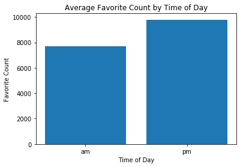

```python
master.groupby('pm')['favorite_count']
plt.bar([1, 2], [7681, 9791], tick_label=['am', 'pm'])
plt.title('Average Favorite Count by Time of Day')
plt.xlabel('Time of Day')
plt.ylabel('Favorite Count');
```

It does appear that people are more likely to favorite tweets sent out during the afternoon and early nighttime. However, if you take into consideration the good chance that people are sleeping through roughly half of the am tweet cycle, it seems as though the difference should be larger than what we're seeing. I'll also add time of day to the regression I'm going to run at the bottom.

Before that, I want to know if weekend tweets get more favorite traction:

```python
master.groupby('weekend')['favorite_count'].describe()
```

| weekend | count | mean | std | min | 25% | 50% | 75% | max |
| --- | --- | --- | --- | --- | --- | --- | --- | --- |
| 0 | 1454.0 | 8660.698074 | 11967.22799 | 76.0 | 1951.0 | 4020.5 | 11016.75 | 125776.0 |
| 1 | 497.0 | 8817.726358 | 14825.51101 | 121.0 | 1692.0 | 3607.0 | 10645.00 | 162705.0 |

## Q3: What's the leading factor in favorite count?

Before running regression, add an intercept column of 1 and convert category variables to dummies.

```python
master['intercept'] = 1
master[['not_dog', 'dog']] = pd.get_dummies(master['is_dog'])
master = master.drop('not_dog', axis=1)
```

```python
master[['None', 'doggo', 'floofer', 'pupper', 'puppo', 'multiple']] = pd.get_dummies(master['dog_type'])
```

```python
master.loc[master.dog_breed == 'golden_retriever', 'golden'] = 1
master.loc[master.dog_breed != 'golden_retriever', 'golden'] = 0
master.loc[master.dog_breed == 'Labrador_retriever', 'lab'] = 1
master.loc[master.dog_breed != 'Labrador_retriever', 'lab'] = 0
```

```python
master['retriever'] = master.golden + master.lab
```

```python
master.golden = master.golden.astype(str).str[:-2].astype(int)
master.lab = master.lab.astype(str).str[:-2].astype(int)
```

```python
master.golden.unique(), master.lab.unique()
```

```
(array([0, 1]), array([0, 1]))
```

```python
logmod = sm.OLS(master.favorite_count.astype(float), master[['intercept', 'multiple', 'floofer', 'doggo', 'puppo', 'pupper', 'weekend','retriever', 'rating_numerator', 'pm']])
res = logmod.fit()
res.summary()
```

OLS Regression Results

| Dep. Variable: | favorite_count | R-squared: | 0.053 |
| --- | --- | --- | --- |
| Model: | OLS | Adj. R-squared: | 0.049 |
| Method: | Least Squares | F-statistic: | 12.12 |
| Date: | Sun, 07 Apr 2019 | Prob (F-statistic): | 8.27e-19 |
| Time: | 22:41:41 | Log-Likelihood: | -21158. |
| No. Observations: | 1951 | AIC: | 4.234e+04 |
| Df Residuals: | 1941 | BIC: | 4.239e+04 |
| Df Model: | 9 |  |  |
| Covariance Type: | nonrobust |  |  |

|  | coef | std err | t | P>\|t\| | [0.025 | 0.975] |
| --- | --- | --- | --- | --- | --- | --- |
| intercept | 6889.2936 | 457.899 | 15.045 | 0.000 | 5991.268 | 7787.319 |
| multiple | 1.288e+04 | 2671.368 | 4.820 | 0.000 | 7638.044 | 1.81e+04 |
| floofer | 4301.2266 | 4712.421 | 0.913 | 0.361 | -4940.713 | 1.35e+04 |
| doggo | 1.12e+04 | 1601.077 | 6.992 | 0.000 | 8055.353 | 1.43e+04 |
| puppo | -1221.7930 | 927.343 | -1.318 | 0.188 | -3040.487 | 596.901 |
| pupper | 8656.6988 | 4168.163 | 2.077 | 0.038 | 482.151 | 1.68e+04 |
| weekend | 183.4573 | 647.131 | 0.283 | 0.777 | -1085.688 | 1452.602 |
| retriever | 2875.0902 | 887.884 | 3.238 | 0.001 | 1133.784 | 4616.397 |
| rating_numerator | 5.9379 | 6.855 | 0.866 | 0.386 | -7.506 | 19.382 |
| pm | 1875.3703 | 564.209 | 3.324 | 0.001 | 768.850 | 2981.890 |

| Omnibus: | 1783.227 | Durbin-Watson: | 1.379 |
| --- | --- | --- | --- |
| Prob(Omnibus): | 0.000 | Jarque-Bera (JB): | 75111.785 |
| Skew: | 4.249 | Prob(JB): | 0.00 |
| Kurtosis: | 32.185 | Cond. No. | 715. |

We also see that weekend has no statistically significant affect on favorite likelihood.

Keep in mind, however, that only about 5% of favorite count is explained by this regression, so it's most likely that the true leading factor was not examined in this model. Still, we were able to find some significant determinants with it.